# Seminar12_eng

## Pandas

In this notebook we will get to know the main features of **pandas**. This library is huge, so we can only play a little with the available functionality. For a detailed review, read the documentation.

### 1. First glance

```python
import pandas as pd  # common alias for pandas
```

```python
# Read dataset from csv file
coins = pd.read_csv('coins.csv')
```

```python
# Let's see what we've got
coins
```

|  | date | price | txCount | txVolume | activeAddresses | symbol | name | open | high | low | close | volume | market |
| --- | --- | --- | --- | --- | --- | --- | --- | --- | --- | --- | --- | --- | --- |
| 0 | 2013-04-28 | 135.300000 | 41702.0 | 6.879868e+07 | 117984.0 | BTC | Bitcoin | 135.300000 | 135.980000 | 132.100000 | 134.210000 | 0.000000e+00 | 1.500520e+09 |
| 1 | 2013-04-28 | 4.300000 | 9174.0 | 4.431952e+07 | 17216.0 | LTC | Litecoin | 4.300000 | 4.400000 | 4.180000 | 4.350000 | 0.000000e+00 | 7.377340e+07 |
| 2 | 2013-04-29 | 134.440000 | 51602.0 | 1.138128e+08 | 86925.0 | BTC | Bitcoin | 134.440000 | 147.490000 | 134.000000 | 144.540000 | 0.000000e+00 | 1.491160e+09 |
| 3 | 2013-04-29 | 4.370000 | 9275.0 | 3.647810e+07 | 18395.0 | LTC | Litecoin | 4.370000 | 4.570000 | 4.230000 | 4.380000 | 0.000000e+00 | 7.495270e+07 |
| 4 | 2013-04-30 | 144.000000 | 47450.0 | 8.426632e+07 | 76871.0 | BTC | Bitcoin | 144.000000 | 146.930000 | 134.050000 | 139.000000 | 0.000000e+00 | 1.597780e+09 |
| 5 | 2013-04-30 | 4.400000 | 9099.0 | 4.039166e+07 | 17810.0 | LTC | Litecoin | 4.400000 | 4.570000 | 4.170000 | 4.300000 | 0.000000e+00 | 7.572680e+07 |
| 6 | 2013-05-01 | 139.000000 | 55176.0 | 1.206825e+08 | 83564.0 | BTC | Bitcoin | 139.000000 | 139.890000 | 107.720000 | 116.990000 | 0.000000e+00 | 1.542820e+09 |
| 7 | 2013-05-01 | 4.290000 | 8990.0 | 7.637420e+07 | 16991.0 | LTC | Litecoin | 4.290000 | 4.360000 | 3.520000 | 3.800000 | 0.000000e+00 | 7.390120e+07 |
| 8 | 2013-05-02 | 116.380000 | 55295.0 | 9.337533e+07 | 81920.0 | BTC | Bitcoin | 116.380000 | 125.600000 | 92.280000 | 105.210000 | 0.000000e+00 | 1.292190e+09 |
| 9 | 2013-05-02 | 3.780000 | 8031.0 | 1.163151e+07 | 15769.0 | LTC | Litecoin | 3.780000 | 4.040000 | 3.010000 | 3.370000 | 0.000000e+00 | 6.524270e+07 |
| 10 | 2013-05-03 | 106.250000 | 51275.0 | 7.273133e+07 | 82804.0 | BTC | Bitcoin | 106.250000 | 108.130000 | 79.100000 | 97.750000 | 0.000000e+00 | 1.180070e+09 |
| 11 | 2013-05-03 | 3.390000 | 6280.0 | 4.632241e+06 | 12956.0 | LTC | Litecoin | 3.390000 | 3.450000 | 2.400000 | 3.040000 | 0.000000e+00 | 5.860740e+07 |
| 12 | 2013-05-04 | 98.100000 | 50102.0 | 3.896570e+07 | 69959.0 | BTC | Bitcoin | 98.100000 | 115.000000 | 92.500000 | 112.500000 | 0.000000e+00 | 1.089890e+09 |
| 13 | 2013-05-04 | 3.030000 | 6168.0 | 5.725030e+06 | 12377.0 | LTC | Litecoin | 3.030000 | 3.640000 | 2.900000 | 3.480000 | 0.000000e+00 | 5.247640e+07 |
| 14 | 2013-05-05 | 112.900000 | 50167.0 | 5.708371e+07 | 72103.0 | BTC | Bitcoin | 112.900000 | 118.800000 | 107.140000 | 115.910000 | 0.000000e+00 | 1.254760e+09 |
| 15 | 2013-05-05 | 3.490000 | 5948.0 | 6.579465e+06 | 12245.0 | LTC | Litecoin | 3.490000 | 3.690000 | 3.350000 | 3.590000 | 0.000000e+00 | 6.052500e+07 |
| 16 | 2013-05-06 | 115.980000 | 53174.0 | 8.567133e+07 | 85164.0 | BTC | Bitcoin | 115.980000 | 124.660000 | 106.640000 | 112.300000 | 0.000000e+00 | 1.289470e+09 |
| 17 | 2013-05-06 | 3.590000 | 10636.0 | 1.348974e+07 | 18244.0 | LTC | Litecoin | 3.590000 | 3.780000 | 3.120000 | 3.370000 | 0.000000e+00 | 6.235600e+07 |
| 18 | 2013-05-07 | 112.250000 | 56567.0 | 9.672451e+07 | 109067.0 | BTC | Bitcoin | 112.250000 | 113.440000 | 97.700000 | 111.500000 | 0.000000e+00 | 1.248470e+09 |
| 19 | 2013-05-07 | 3.370000 | 8712.0 | 9.082298e+06 | 16710.0 | LTC | Litecoin | 3.370000 | 3.410000 | 2.940000 | 3.330000 | 0.000000e+00 | 5.858830e+07 |
| 20 | 2013-05-08 | 109.600000 | 50274.0 | 7.989088e+07 | 102388.0 | BTC | Bitcoin | 109.600000 | 115.780000 | 109.600000 | 113.570000 | 0.000000e+00 | 1.219450e+09 |
| 21 | 2013-05-08 | 3.280000 | 9035.0 | 6.748147e+06 | 16851.0 | LTC | Litecoin | 3.280000 | 3.490000 | 3.280000 | 3.410000 | 0.000000e+00 | 5.719630e+07 |
| 22 | 2013-05-09 | 113.200000 | 66610.0 | 6.453970e+07 | 81894.0 | BTC | Bitcoin | 113.200000 | 113.460000 | 109.260000 | 112.670000 | 0.000000e+00 | 1.259980e+09 |
| 23 | 2013-05-09 | 3.400000 | 12776.0 | 9.291191e+06 | 20459.0 | LTC | Litecoin | 3.400000 | 3.440000 | 3.290000 | 3.420000 | 0.000000e+00 | 5.933710e+07 |
| 24 | 2013-05-10 | 112.800000 | 67709.0 | 7.883246e+07 | 84293.0 | BTC | Bitcoin | 112.800000 | 122.000000 | 111.550000 | 117.200000 | 0.000000e+00 | 1.255970e+09 |
| 25 | 2013-05-10 | 3.410000 | 10503.0 | 8.136962e+06 | 18054.0 | LTC | Litecoin | 3.410000 | 3.630000 | 3.370000 | 3.440000 | 0.000000e+00 | 5.958800e+07 |
| 26 | 2013-05-11 | 117.700000 | 73220.0 | 6.724575e+07 | 80910.0 | BTC | Bitcoin | 117.700000 | 118.680000 | 113.010000 | 115.240000 | 0.000000e+00 | 1.311050e+09 |
| 27 | 2013-05-11 | 3.460000 | 7000.0 | 1.868224e+07 | 14207.0 | LTC | Litecoin | 3.460000 | 3.480000 | 3.300000 | 3.350000 | 0.000000e+00 | 6.065800e+07 |
| 28 | 2013-05-12 | 115.640000 | 65260.0 | 5.295803e+07 | 69607.0 | BTC | Bitcoin | 115.640000 | 117.450000 | 113.440000 | 115.000000 | 0.000000e+00 | 1.288630e+09 |
| 29 | 2013-05-12 | 3.360000 | 6924.0 | 8.487886e+06 | 13924.0 | LTC | Litecoin | 3.360000 | 3.420000 | 3.220000 | 3.270000 | 0.000000e+00 | 5.905290e+07 |
| ... | ... | ... | ... | ... | ... | ... | ... | ... | ... | ... | ... | ... | ... |
| 37558 | 2018-06-06 | 0.501701 | 23.0 | 7.848460e+04 | 24.0 | MAID | MaidSafeCoin | 0.501701 | 0.504054 | 0.454453 | 0.472970 | 3.113110e+06 | 2.270460e+08 |
| 37559 | 2018-06-06 | 0.099070 | 272.0 | 6.854031e+05 | 198.0 | MANA | Decentraland | 0.099070 | 0.106756 | 0.096538 | 0.105576 | 6.702560e+06 | 1.040380e+08 |
| 37560 | 2018-06-06 | 2.750000 | 42.0 | 2.140964e+06 | 46.0 | MTL | Metal | 2.750000 | 2.750000 | 2.640000 | 2.690000 | 1.019210e+07 | 6.773980e+07 |
| 37561 | 2018-06-06 | 7.280000 | 177.0 | 4.494855e+06 | 197.0 | NAS | Nebulas | 7.280000 | 7.430000 | 7.070000 | 7.200000 | 4.103980e+07 | 3.310870e+08 |
| 37562 | 2018-06-06 | 54.510000 | 18273.0 | 1.209127e+08 | 7785.0 | NEO | NEO | 54.510000 | 54.610000 | 52.750000 | 53.920000 | 8.157260e+07 | 3.543110e+09 |
| 37563 | 2018-06-06 | 11.330000 | 1196.0 | 1.280214e+07 | 985.0 | OMG | OmiseGO | 11.330000 | 11.360000 | 10.800000 | 11.070000 | 4.893110e+07 | 1.155730e+09 |
| 37564 | 2018-06-06 | 0.908094 | 238.0 | 2.592834e+05 | 218.0 | PAY | TenX | 0.908094 | 0.912381 | 0.879816 | 0.894405 | 5.604010e+06 | 9.902520e+07 |
| 37565 | 2018-06-06 | 3.750000 | 916.0 | 8.075333e+06 | 2866.0 | PIVX | PIVX | 3.750000 | 3.830000 | 3.650000 | 3.760000 | 2.009340e+06 | 2.116430e+08 |
| 37566 | 2018-06-06 | 0.679197 | 194.0 | 1.031787e+06 | 208.0 | POLY | Polymath | 0.679197 | 0.687892 | 0.660005 | 0.669440 | 2.447040e+06 | 1.877440e+08 |
| 37567 | 2018-06-06 | 0.339788 | 260.0 | 7.269057e+05 | 211.0 | POWR | Power Ledger | 0.339788 | 0.347761 | 0.333961 | 0.337927 | 2.295680e+06 | 1.268790e+08 |
| 37568 | 2018-06-06 | 12.310000 | 269.0 | 2.923877e+06 | 268.0 | PPT | Populous | 12.310000 | 12.340000 | 11.590000 | 11.990000 | 5.196670e+06 | 4.556540e+08 |
| 37569 | 2018-06-06 | 0.512563 | 87.0 | 4.282407e+05 | 105.0 | QASH | QASH | 0.512563 | 0.516133 | 0.495789 | 0.506310 | 1.504760e+06 | 1.793970e+08 |
| 37570 | 2018-06-06 | 38.070000 | 438.0 | 2.743461e+06 | 344.0 | REP | Augur | 38.070000 | 38.450000 | 37.200000 | 38.140000 | 2.999650e+06 | 4.187970e+08 |
| 37571 | 2018-06-06 | 1.430000 | 86.0 | 4.535287e+06 | 90.0 | RHOC | RChain | 1.430000 | 1.450000 | 1.350000 | 1.360000 | 1.025180e+06 | 5.147300e+08 |
| 37572 | 2018-06-06 | 2.010000 | 372.0 | 1.375369e+06 | 318.0 | SALT | SALT | 2.010000 | 2.020000 | 1.900000 | 1.950000 | 3.900790e+06 | 1.183970e+08 |
| 37573 | 2018-06-06 | 0.098329 | 416.0 | 1.851701e+06 | 311.0 | SNT | Status | 0.098329 | 0.098763 | 0.094189 | 0.096062 | 2.028040e+07 | 3.412490e+08 |
| 37574 | 2018-06-06 | 0.306995 | 135.0 | 5.499680e+05 | 113.0 | SRN | SIRIN LABS Token | 0.306995 | 0.307789 | 0.293147 | 0.300307 | 4.901450e+06 | 7.038110e+07 |
| 37575 | 2018-06-06 | 0.060621 | 4804.0 | 4.692310e+07 | 3318.0 | TRX | TRON | 0.060621 | 0.060650 | 0.058435 | 0.059408 | 1.883140e+08 | 3.985740e+09 |
| 37576 | 2018-06-06 | 0.997917 | 8648.0 | 2.820854e+08 | 4341.0 | USDT | Tether | 0.997917 | 1.010000 | 0.990877 | 1.000000 | 2.508360e+09 | 2.501920e+09 |
| 37577 | 2018-06-06 | NaN | 603.0 | NaN | 528.0 | VEN | VeChain | 4.100000 | 4.880000 | 3.990000 | 4.140000 | 1.205590e+08 | 2.154240e+09 |
| 37578 | 2018-06-06 | 88.080000 | 172.0 | 1.310279e+06 | 162.0 | VERI | Veritaseum | 88.080000 | 94.080000 | 85.720000 | 88.600000 | 9.196140e+05 | 1.793920e+08 |
| 37579 | 2018-06-06 | 1.600000 | 1275.0 | 2.235414e+05 | 3211.0 | VTC | Vertcoin | 1.600000 | 1.610000 | 1.530000 | 1.550000 | 8.382230e+05 | 7.142090e+07 |
| 37580 | 2018-06-06 | 4.330000 | 59491.0 | 3.447123e+06 | 5491.0 | WAVES | Waves | 4.330000 | 4.350000 | 4.240000 | 4.320000 | 2.493120e+07 | 4.326770e+08 |
| 37581 | 2018-06-06 | 12.120000 | 200.0 | 5.920692e+05 | 209.0 | WTC | Waltonchain | 12.120000 | 12.920000 | 11.820000 | 12.900000 | 1.126420e+07 | 3.775560e+08 |
| 37582 | 2018-06-06 | 0.252141 | 6613.0 | 3.267675e+06 | 3231.0 | XEM | NEM | 0.252141 | 0.252469 | 0.245758 | 0.250975 | 1.644680e+07 | 2.269270e+09 |
| 37583 | 2018-06-06 | 0.293325 | 4830.0 | 2.312763e+05 | 659.0 | XLM | Stellar | 0.293325 | 0.299955 | 0.289500 | 0.298269 | 5.116500e+07 | 5.450080e+09 |
| 37584 | 2018-06-06 | 0.039586 | 7205.0 | 4.947760e+06 | 18228.0 | XVG | Verge | 0.039586 | 0.039737 | 0.037680 | 0.038797 | 9.307450e+06 | 5.959400e+08 |
| 37585 | 2018-06-06 | 239.760000 | 10687.0 | 3.986308e+07 | 96516.0 | ZEC | Zcash | 239.750000 | 240.340000 | 229.210000 | 236.050000 | 5.688700e+07 | 9.769940e+08 |
| 37586 | 2018-06-06 | 0.127555 | 1313.0 | 1.596436e+07 | 733.0 | ZIL | Zilliqa | 0.127555 | 0.133254 | 0.124194 | 0.131766 | 5.466790e+07 | 9.348810e+08 |
| 37587 | 2018-06-06 | 1.270000 | 795.0 | 6.094435e+06 | 599.0 | ZRX | 0x | 1.270000 | 1.340000 | 1.250000 | 1.330000 | 1.777800e+07 | 6.741510e+08 |

37588 rows × 13 columns

column descriptions:

- date - date of measurement
- name - coin's name
- symbol - coin's symbol
- price - average coin price per trading day in USD
- txCount - the number of transactions in the coin network
- txVolume - coin's volume transferred between the coin network addresses
- activeAddresses - the number of addresses that transacted on the trading day in the coin network
- open - coin price at the beginning of the trading day
- close - coin price at the end of the trading day
- high - highest coin price during the trading day
- low - lowest coin price during the trading day
- volume - trading volume of this coin on exchanges on the trading day
- market - capitalization of this coin on the trading day

From output you can get a general idea of the table. You can see that the table can store both numeric and categorical (string) data, the number of rows and columns. All this information and much more can be obtained in the code.

For convenience, we will further limit the size of pandas output in jupyter notebook.

```python
pd.set_option('display.max_rows', 10)
```

```python
coins.shape  # Table's size
```

```
(37588, 13)
```

```python
coins.head(3)  #  First three rows of the table. use .tail(n) for a number of last rows
```

|  | date | price | txCount | txVolume | activeAddresses | symbol | name | open | high | low | close | volume | market |
| --- | --- | --- | --- | --- | --- | --- | --- | --- | --- | --- | --- | --- | --- |
| 0 | 2013-04-28 | 135.30 | 41702.0 | 6.879868e+07 | 117984.0 | BTC | Bitcoin | 135.30 | 135.98 | 132.10 | 134.21 | 0.0 | 1.500520e+09 |
| 1 | 2013-04-28 | 4.30 | 9174.0 | 4.431952e+07 | 17216.0 | LTC | Litecoin | 4.30 | 4.40 | 4.18 | 4.35 | 0.0 | 7.377340e+07 |
| 2 | 2013-04-29 | 134.44 | 51602.0 | 1.138128e+08 | 86925.0 | BTC | Bitcoin | 134.44 | 147.49 | 134.00 | 144.54 | 0.0 | 1.491160e+09 |

```python
coins.describe()  # Simple statistics for numeric columns
```

|  | price | txCount | txVolume | activeAddresses | open | high | low | close | volume | market |
| --- | --- | --- | --- | --- | --- | --- | --- | --- | --- | --- |
| count | 37261.000000 | 3.606800e+04 | 3.575800e+04 | 3.606800e+04 | 37588.000000 | 37588.000000 | 37588.000000 | 37588.000000 | 3.758800e+04 | 3.758800e+04 |
| mean | 127.395042 | 1.960144e+04 | 4.745076e+53 | 3.295039e+04 | 125.652051 | 131.127449 | 119.791636 | 125.771519 | 1.302249e+08 | 2.720948e+09 |
| std | 859.109058 | 7.702995e+04 | 8.972837e+55 | 1.143196e+05 | 855.436562 | 890.527305 | 813.697042 | 855.954704 | 8.042239e+08 | 1.534546e+10 |
| min | 0.000002 | 0.000000e+00 | 0.000000e+00 | 0.000000e+00 | 0.000002 | 0.000003 | 0.000002 | 0.000002 | 0.000000e+00 | 0.000000e+00 |
| 25% | 0.059871 | 3.410000e+02 | 2.751161e+05 | 2.920000e+02 | 0.053032 | 0.057809 | 0.049289 | 0.053147 | 8.794400e+04 | 1.356655e+07 |
| 50% | 1.020000 | 1.214500e+03 | 2.007019e+06 | 1.388000e+03 | 1.000000 | 1.050000 | 1.000000 | 1.000000 | 1.949815e+06 | 1.323890e+08 |
| 75% | 8.710000 | 6.247000e+03 | 1.425408e+07 | 1.173400e+04 | 8.772500 | 9.480000 | 8.150000 | 8.810000 | 1.770732e+07 | 5.156410e+08 |
| max | 19475.800000 | 1.349890e+06 | 1.696744e+58 | 1.283929e+06 | 19475.800000 | 20089.000000 | 18974.100000 | 19497.400000 | 2.384090e+10 | 3.261410e+11 |

```python
coins['price']  # A column can be selected
```

```
0        135.300000
1          4.300000
2        134.440000
3          4.370000
4        144.000000
            ...
37583      0.293325
37584      0.039586
37585    239.760000
37586      0.127555
37587      1.270000
Name: price, Length: 37588, dtype: float64
```

```python
coins['high'] - coins['low']  # element-wise operations work on columns
```

```
0         3.880000
1         0.220000
2        13.490000
3         0.340000
4        12.880000
           ...
37583     0.010455
37584     0.002057
37585    11.130000
37586     0.009060
37587     0.090000
Length: 37588, dtype: float64
```

```python
coins['spread'] = coins['high'] - coins['low']  # New columns can be added to the table
```

```python
del coins['spread']  # Removing a column. Alternative: coins.pop('spread')
```

Columns in pandas tables behave like arrays of fixed length. The nice difference is that the columns have many useful analytic methods. For example,

```python
coins['symbol'].value_counts() # Number of rows for each coin
```

```
LTC      1866
BTC      1866
DOGE     1635
VTC      1599
DGB      1582
         ...
ZIL       133
POLY      125
CENNZ      86
LOOM       85
CTXC       52
Name: symbol, Length: 66, dtype: int64
```

```python
# Maximum value for price column
coins['price'].max()
```

```
19475.8
```

**Task**: How many different coins are in the dataset?

```python
# your code here
```

```python
# Standard indexing works
coins['txVolume'][:4]
```

```
0    6.879868e+07
1    4.431952e+07
2    1.138128e+08
3    3.647810e+07
Name: txVolume, dtype: float64
```

Boolean masks also work

```python
coins['txCount'] > 1000
```

```
0         True
1         True
2         True
3         True
4         True
         ...
37583     True
37584     True
37585     True
37586     True
37587    False
Name: txCount, Length: 37588, dtype: bool
```

```python
# Rows with txCount > 1000
coins[coins['txCount'] > 1000]
```

|  | date | price | txCount | txVolume | activeAddresses | symbol | name | open | high | low | close | volume | market |
| --- | --- | --- | --- | --- | --- | --- | --- | --- | --- | --- | --- | --- | --- |
| 0 | 2013-04-28 | 135.300000 | 41702.0 | 6.879868e+07 | 117984.0 | BTC | Bitcoin | 135.300000 | 135.980000 | 132.100000 | 134.210000 | 0.0 | 1.500520e+09 |
| 1 | 2013-04-28 | 4.300000 | 9174.0 | 4.431952e+07 | 17216.0 | LTC | Litecoin | 4.300000 | 4.400000 | 4.180000 | 4.350000 | 0.0 | 7.377340e+07 |
| 2 | 2013-04-29 | 134.440000 | 51602.0 | 1.138128e+08 | 86925.0 | BTC | Bitcoin | 134.440000 | 147.490000 | 134.000000 | 144.540000 | 0.0 | 1.491160e+09 |
| 3 | 2013-04-29 | 4.370000 | 9275.0 | 3.647810e+07 | 18395.0 | LTC | Litecoin | 4.370000 | 4.570000 | 4.230000 | 4.380000 | 0.0 | 7.495270e+07 |
| 4 | 2013-04-30 | 144.000000 | 47450.0 | 8.426632e+07 | 76871.0 | BTC | Bitcoin | 144.000000 | 146.930000 | 134.050000 | 139.000000 | 0.0 | 1.597780e+09 |
| ... | ... | ... | ... | ... | ... | ... | ... | ... | ... | ... | ... | ... | ... |
| 37582 | 2018-06-06 | 0.252141 | 6613.0 | 3.267675e+06 | 3231.0 | XEM | NEM | 0.252141 | 0.252469 | 0.245758 | 0.250975 | 16446800.0 | 2.269270e+09 |
| 37583 | 2018-06-06 | 0.293325 | 4830.0 | 2.312763e+05 | 659.0 | XLM | Stellar | 0.293325 | 0.299955 | 0.289500 | 0.298269 | 51165000.0 | 5.450080e+09 |
| 37584 | 2018-06-06 | 0.039586 | 7205.0 | 4.947760e+06 | 18228.0 | XVG | Verge | 0.039586 | 0.039737 | 0.037680 | 0.038797 | 9307450.0 | 5.959400e+08 |
| 37585 | 2018-06-06 | 239.760000 | 10687.0 | 3.986308e+07 | 96516.0 | ZEC | Zcash | 239.750000 | 240.340000 | 229.210000 | 236.050000 | 56887000.0 | 9.769940e+08 |
| 37586 | 2018-06-06 | 0.127555 | 1313.0 | 1.596436e+07 | 733.0 | ZIL | Zilliqa | 0.127555 | 0.133254 | 0.124194 | 0.131766 | 54667900.0 | 9.348810e+08 |

19365 rows × 13 columns

```python
# coin's symbol is BTC or ADA
coins['symbol'].isin(['BTC', 'ADA'])
```

```
0         True
1        False
2         True
3        False
4         True
         ...
37583    False
37584    False
37585    False
37586    False
37587    False
Name: symbol, Length: 37588, dtype: bool
```

```python
# symbol contains 'C'
coins['symbol'].str.contains('C')
```

```
0         True
1         True
2         True
3         True
4         True
         ...
37583    False
37584    False
37585     True
37586    False
37587    False
Name: symbol, Length: 37588, dtype: bool
```

```python
# Complex conditions (brackets are mandatory!)
((coins['price'] > 18000) | (coins['market'] > 200000)) & (coins['symbol'] == 'BTC')
```

```
0         True
1        False
2         True
3        False
4         True
         ...
37583    False
37584    False
37585    False
37586    False
37587    False
Length: 37588, dtype: bool
```

The main purpose of the resulting boolean columns is that they can be used as an indexing object. A kind of advanced slicing for columns and tables

```python
# Rows with BTC priced less than 100 USD
coins[(coins['price'] < 100) & (coins['symbol'] == 'BTC')]
```

|  | date | price | txCount | txVolume | activeAddresses | symbol | name | open | high | low | close | volume | market |
| --- | --- | --- | --- | --- | --- | --- | --- | --- | --- | --- | --- | --- | --- |
| 12 | 2013-05-04 | 98.10 | 50102.0 | 3.896570e+07 | 69959.0 | BTC | Bitcoin | 98.10 | 115.00 | 92.50 | 112.50 | 0.0 | 1.089890e+09 |
| 98 | 2013-06-16 | 99.80 | 42781.0 | 4.696943e+07 | 48785.0 | BTC | Bitcoin | 99.80 | 101.60 | 98.95 | 99.51 | 0.0 | 1.127120e+09 |
| 100 | 2013-06-17 | 99.90 | 45798.0 | 5.455223e+07 | 56902.0 | BTC | Bitcoin | 99.90 | 102.21 | 99.00 | 101.70 | 0.0 | 1.128720e+09 |
| 124 | 2013-06-29 | 94.66 | 36376.0 | 4.519440e+07 | 60980.0 | BTC | Bitcoin | 94.66 | 99.99 | 93.00 | 94.99 | 0.0 | 1.074010e+09 |
| 126 | 2013-06-30 | 95.00 | 30800.0 | 3.584930e+07 | 50485.0 | BTC | Bitcoin | 95.00 | 98.12 | 94.22 | 96.61 | 0.0 | 1.078260e+09 |
| ... | ... | ... | ... | ... | ... | ... | ... | ... | ... | ... | ... | ... | ... |
| 176 | 2013-07-25 | 94.50 | 42384.0 | 7.153660e+07 | 66440.0 | BTC | Bitcoin | 94.50 | 97.33 | 93.87 | 96.90 | 0.0 | 1.082800e+09 |
| 178 | 2013-07-26 | 96.95 | 37209.0 | 7.056459e+07 | 62558.0 | BTC | Bitcoin | 96.95 | 97.47 | 96.00 | 96.02 | 0.0 | 1.111160e+09 |
| 180 | 2013-07-27 | 96.02 | 36711.0 | 4.158844e+07 | 52438.0 | BTC | Bitcoin | 96.02 | 97.00 | 93.00 | 94.12 | 0.0 | 1.100900e+09 |
| 182 | 2013-07-28 | 94.40 | 37134.0 | 5.463939e+07 | 49179.0 | BTC | Bitcoin | 94.40 | 100.58 | 94.00 | 99.76 | 0.0 | 1.082750e+09 |
| 184 | 2013-07-29 | 98.60 | 41634.0 | 7.030931e+07 | 67473.0 | BTC | Bitcoin | 98.60 | 102.50 | 98.45 | 101.20 | 0.0 | 1.131340e+09 |

34 rows × 13 columns

```python
# Transactions count for litecoin
coins['txCount'][coins['symbol'] == 'LTC']
```

```
1         9174.0
3         9275.0
5         9099.0
7         8990.0
9         8031.0
          ...
37277    22879.0
37347    22155.0
37417    24326.0
37487    25172.0
37557    25346.0
Name: txCount, Length: 1866, dtype: float64
```

**Task**: What coin has the maximum price?

```python
# your code here
```

Table indexing works both for rows and columns

```python
# highest price and volume for days when DOGE has been priced greater than 1 cent
coins.loc[
    (coins['symbol'] == 'DOGE') & (coins['price'] > 0.01),
    ['high', 'volume']
]
```

|  | high | volume |
| --- | --- | --- |
| 27257 | 0.015788 | 283717000.0 |
| 27322 | 0.018773 | 288184000.0 |
| 27387 | 0.017664 | 235114000.0 |
| 27452 | 0.015569 | 115255000.0 |
| 27517 | 0.013560 | 100243000.0 |
| 27582 | 0.013153 | 62722000.0 |
| 27647 | 0.013339 | 56971300.0 |
| 27712 | 0.013653 | 55890600.0 |
| 27777 | 0.013187 | 65899000.0 |
| 27842 | 0.011779 | 62765500.0 |

```python
# TAB-completions!!!
list.
```

From now on, you can already make simple sets from the data and transform them a bit. Of course, remember to use help() and tab-completion to learn more about the features of pandas. It’s worth keeping this rule in mind: if you really want to use a loop to iterate through the table and do something with the data, it is very likely that you are doing something wrong and, most likely, pandas has a tool for your task. The rest of this notebook is dedicated to pandas features, and it may seem boring, but without knowing these features you will be reinventing the wheel each time.

### 2. Global settings

You might want to configure pandas. Most global settings relate to displaying a table or data.

```python
# get the maximum number of columns being displayed
pd.get_option('display.max_columns')
```

```
20
```

```python
# To find out more about an option.
# The full list of options: https://pandas.pydata.org/pandas-docs/version/0.23.4/options.html#available-options
pd.describe_option('display.max_columns')
```

```
display.max_columns : int
    If max_cols is exceeded, switch to truncate view. Depending on
    `large_repr`, objects are either centrally truncated or printed as
    a summary view. 'None' value means unlimited.

    In case python/IPython is running in a terminal and `large_repr`
    equals 'truncate' this can be set to 0 and pandas will auto-detect
    the width of the terminal and print a truncated object which fits
    the screen width. The IPython notebook, IPython qtconsole, or IDLE
    do not run in a terminal and hence it is not possible to do
    correct auto-detection.
    [default: 20] [currently: 20]
```

```python
# set the maximum number of columns being displayed
pd.set_option('display.max_columns', 15)
```

### 3. Data types in pandas

There are two main types of data in pandas - pandas.Series and pandas.DataFrame.

#### 3.1 pandas.Series

Pandas.Series should be thought of as a one-dimensional array of a fixed size with data of the same type. Unlike arrays, access to elements can be at a non-numeric index. An index should be understood as row name.

pandas.Series objects are very often used as return values in pandas.

```python
# pandas.Series with standard indexes
pd.Series(data=['BTC', 'LTC', 'DOGE', 'DASH'])
```

```
0     BTC
1     LTC
2    DOGE
3    DASH
dtype: object
```

```python
# pandas.Series with str indexes
pd.Series(data=['BTC', 'ETH', 'XRP'],
          index=['first_coin', 'second_coin', 'third_coin'], dtype=str)
```

```
first_coin     BTC
second_coin    ETH
third_coin     XRP
dtype: object
```

```python
# casting a dictionary
pd.Series({'first_coin': 'BTC', 'second_coin': 'ETH', 'third_coin': 'XRP'})
```

```
first_coin     BTC
second_coin    ETH
third_coin     XRP
dtype: object
```

```python
sequence = pd.Series(data=['!', 'the', 'Moon', 'To'])
sequence[[3, 1, 2, 0, 0, 0]]  # Access elements by indexes
```

```
3      To
1     the
2    Moon
0       !
0       !
0       !
dtype: object
```

```python
sequence[3]  # Getting an element by its index
```

```
'To'
```

```python
# Works with non-standard indexes too
sequence = pd.Series(data=['!', 'the', 'Moon', 'To'],
                     index=['04-11-2018', '02-11-2018', '03-11-2018', '01-11-2018'])
```

```python
sequence[['01-11-2018', '02-11-2018', '03-11-2018', '04-11-2018']]
```

```
01-11-2018      To
02-11-2018     the
03-11-2018    Moon
04-11-2018       !
dtype: object
```

```python
sequence['01-11-2018']
```

```
'To'
```

```python
# Remove an object
del sequence
```

#### 3.2 pandas.DataFrame

pandas.DataFrame is a two-dimensional array of variable size with heterogeneous data (but of the same type within each column). It’s better to think of pandas.DataFrame as a set of columns, where each column is of pandas.Series type.

```python
# Create a table
pd.DataFrame(data=['BTC', 'LTC', 'XRP'])
```

|  | 0 |
| --- | --- |
| 0 | BTC |
| 1 | LTC |
| 2 | XRP |

```python
# Create a table with specified names of columns
pd.DataFrame(data=[['BTC', 10000],['LTC', 200],['XRP', 1]],
             columns=['symbol', 'price'])
```

|  | symbol | price |
| --- | --- | --- |
| 0 | BTC | 10000 |
| 1 | LTC | 200 |
| 2 | XRP | 1 |

```python
# And now with specific indexes also
pd.DataFrame(
    data=[['BTC', 10000],['LTC', 200],['XRP', 1]],
    columns=['symbol', 'price'],
    index=pd.DatetimeIndex(['01-11-2018', '03-11-2018', '23-08-2018'])
)
```

|  | symbol | price |
| --- | --- | --- |
| 2018-01-11 | BTC | 10000 |
| 2018-03-11 | LTC | 200 |
| 2018-08-23 | XRP | 1 |

```python
# Create a table from a set of pandas.Series
pd.DataFrame({
    'symbol': pd.Series(data=['BTC','LTC'], index=pd.DatetimeIndex(['01-11-2018', '03-11-2018'])),
    'price': pd.Series(data=[10000, 200], index=pd.DatetimeIndex(['01-11-2018', '03-11-2018']))
})
```

|  | symbol | price |
| --- | --- | --- |
| 2018-01-11 | BTC | 10000 |
| 2018-03-11 | LTC | 200 |

### 4. Basic methods of pandas.Series

```python
sequence = pd.Series(data=['BTC', 'LTC', 'DOGE', 'DASH'], index=['leader', 'alternative', 'joke', 'bouncer'])
```

```python
# Get indexes
sequence.axes
```

```
[Index(['leader', 'alternative', 'joke', 'bouncer'], dtype='object')]
```

```python
# Get type of the data
sequence.dtype
```

```
dtype('O')
```

```python
# Check if empty
sequence.empty
```

```
False
```

```python
# Number of dimensions. Always 1 for pandas.Series
sequence.ndim
```

```
1
```

```python
# Number of elements
sequence.size
```

```
4
```

```python
# Sizes
sequence.shape
```

```
(4,)
```

```python
# Cast to numpy array
sequence.values
```

```
array(['BTC', 'LTC', 'DOGE', 'DASH'], dtype=object)
```

```python
# Get first three elements
sequence.head(3)
```

```
leader          BTC
alternative     LTC
joke           DOGE
dtype: object
```

```python
# Get last two elements
sequence.tail(2)
```

```
joke       DOGE
bouncer    DASH
dtype: object
```

```python
del sequence
```

### 5. Basic methods of pandas.DataFrame

DataFrame is huge so we will look only at the most frequently used methods

```python
table = pd.DataFrame(
    data=[['BTC', 10000],['LTC', 200],['XRP', 1]],
    columns=['symbol', 'price'],
    index=pd.DatetimeIndex(['01-11-2018', '03-11-2018', '23-08-2018'])
)
```

```python
# Transpose table
table.T
```

|  | 2018-01-11 00:00:00 | 2018-03-11 00:00:00 | 2018-08-23 00:00:00 |
| --- | --- | --- | --- |
| symbol | BTC | LTC | XRP |
| price | 10000 | 200 | 1 |

```python
# Get indexes
table.axes
```

```
[DatetimeIndex(['2018-01-11', '2018-03-11', '2018-08-23'], dtype='datetime64[ns]', freq=None),
 Index(['symbol', 'price'], dtype='object')]
```

```python
# Get data types
table.dtypes
```

```
symbol    object
price      int64
dtype: object
```

```python
# Check if empty
table.empty
```

```
False
```

```python
# Sizes
table.shape
```

```
(3, 2)
```

```python
# Number of cells
table.size
```

```
6
```

```python
# Cast to numpy ndarray
table.values
```

```
array([['BTC', 10000],
       ['LTC', 200],
       ['XRP', 1]], dtype=object)
```

```python
# Get first three rows
table.head(3)
```

|  | symbol | price |
| --- | --- | --- |
| 2018-01-11 | BTC | 10000 |
| 2018-03-11 | LTC | 200 |
| 2018-08-23 | XRP | 1 |

```python
# Get last two rows
table.tail(2)
```

|  | symbol | price |
| --- | --- | --- |
| 2018-03-11 | LTC | 200 |
| 2018-08-23 | XRP | 1 |

```python
del table
```

### 6. Working with rows and columns

We can get rows either by indexes or by ordinal numbers

```python
table = pd.DataFrame(
    data=[['BTC', 10000],['LTC', 200],['XRP', 1], ['BTC', 9000]],
    columns=['symbol', 'price'],
    index=pd.DatetimeIndex(['01-11-2018', '03-11-2018', '23-08-2018', '02-11-2018'])
)
table
```

|  | symbol | price |
| --- | --- | --- |
| 2018-01-11 | BTC | 10000 |
| 2018-03-11 | LTC | 200 |
| 2018-08-23 | XRP | 1 |
| 2018-02-11 | BTC | 9000 |

#### 6.1. Getting rows

```python
# By ordinal number
table.iloc[2]
```

```
symbol    XRP
price       1
Name: 2018-08-23 00:00:00, dtype: object
```

```python
# By range of numbers
table[1:3]
```

|  | symbol | price |
| --- | --- | --- |
| 2018-03-11 | LTC | 200 |
| 2018-08-23 | XRP | 1 |

```python
# By index
table.loc[pd.Timestamp('01-11-2018')]
```

```
symbol      BTC
price     10000
Name: 2018-01-11 00:00:00, dtype: object
```

```python
# By range of indexes
table.loc['01-11-2018':'03-11-2019']
```

|  | symbol | price |
| --- | --- | --- |
| 2018-01-11 | BTC | 10000 |
| 2018-03-11 | LTC | 200 |
| 2018-08-23 | XRP | 1 |
| 2018-02-11 | BTC | 9000 |

#### 6.2. Adding, removing and renaming rows and columns

```python
# Remove rows by indexes.  Can be used for column removal with axis=1 parameter.
# See also drop_duplicates and dropna
table.drop([pd.Timestamp('2018-08-23'), pd.Timestamp('2018-01-11')])
```

|  | symbol | price |
| --- | --- | --- |
| 2018-03-11 | LTC | 200 |
| 2018-02-11 | BTC | 9000 |

```python
# Add new column
table['volume'] = [1e9, 1e6, 1e4, 1e9]
table
```

|  | symbol | price | volume |
| --- | --- | --- | --- |
| 2018-01-11 | BTC | 10000 | 1.000000e+09 |
| 2018-03-11 | LTC | 200 | 1.000000e+06 |
| 2018-08-23 | XRP | 1 | 1.000000e+04 |
| 2018-02-11 | BTC | 9000 | 1.000000e+09 |

```python
# Remove a column
del table['volume']
```

```python
# Rename columns
table.rename(columns={'symbol': 'Symbol', 'price': 'Price'})
```

|  | Symbol | Price |
| --- | --- | --- |
| 2018-01-11 | BTC | 10000 |
| 2018-03-11 | LTC | 200 |
| 2018-08-23 | XRP | 1 |
| 2018-02-11 | BTC | 9000 |

#### 6.3. Iterating

Iterating through a table can be done in a number of ways. But better not to use loops at all, use pandas methods instead.

```python
# By columns
for column in table:
    print(column)
```

```
symbol
price
```

```python
# By columns as dictionaries
for column, series in table.iteritems():
    print(column)
    print(series)
```

```
symbol
2018-01-11    BTC
2018-03-11    LTC
2018-08-23    XRP
2018-02-11    BTC
Name: symbol, dtype: object
price
2018-01-11    10000
2018-03-11      200
2018-08-23        1
2018-02-11     9000
Name: price, dtype: int64
```

```python
# By rows as dictionaries
for index, row in table.iterrows():
    print(index)
    print(row)
```

```
2018-01-11 00:00:00
symbol      BTC
price     10000
Name: 2018-01-11 00:00:00, dtype: object
2018-03-11 00:00:00
symbol    LTC
price     200
Name: 2018-03-11 00:00:00, dtype: object
2018-08-23 00:00:00
symbol    XRP
price       1
Name: 2018-08-23 00:00:00, dtype: object
2018-02-11 00:00:00
symbol     BTC
price     9000
Name: 2018-02-11 00:00:00, dtype: object
```

#### 6.4. Sorting

Rows and columns of the table can be sorted. Sorting methods return a new table!

```python
# Sort rows in decreasing order of index
table.sort_index(ascending=False)
```

|  | symbol | price |
| --- | --- | --- |
| 2018-08-23 | XRP | 1 |
| 2018-03-11 | LTC | 200 |
| 2018-02-11 | BTC | 9000 |
| 2018-01-11 | BTC | 10000 |

```python
# Sort columns in increasing order of names
table.sort_index(axis=1, ascending=True)
```

|  | price | symbol |
| --- | --- | --- |
| 2018-01-11 | 10000 | BTC |
| 2018-03-11 | 200 | LTC |
| 2018-08-23 | 1 | XRP |
| 2018-02-11 | 9000 | BTC |

```python
# Sort rows by symbol, price using quicksort algorithm
table.sort_values(by=['symbol', 'price'], kind='quicksort')
```

|  | symbol | price |
| --- | --- | --- |
| 2018-02-11 | BTC | 9000 |
| 2018-01-11 | BTC | 10000 |
| 2018-03-11 | LTC | 200 |
| 2018-08-23 | XRP | 1 |

### 7. Stat functions

Let's see how pandas allows you to calculate the simplest statistics for datasets. The methods that we list below have the axis argument, which indicates along which axis statistics should be calculated. By default axis = 0, which corresponds to row-based calculations. If there are gaps in the data, then they are not taken into account when calculating statistics!

```python
earnings = pd.DataFrame(
    data=[[7629.39, -9357.49, -1661.3, 8597.23],
          [560.68, None, 10.46, 3578.5],
          [487.38, 7560.38, 1090.87, -5164.93]],
    columns=['BTC', 'DOGE', 'ADA', 'ETH'],
    index=['yesterday', 'today', 'tomorrow']
)
earnings
```

|  | BTC | DOGE | ADA | ETH |
| --- | --- | --- | --- | --- |
| yesterday | 7629.39 | -9357.49 | -1661.30 | 8597.23 |
| today | 560.68 | NaN | 10.46 | 3578.50 |
| tomorrow | 487.38 | 7560.38 | 1090.87 | -5164.93 |

```python
# Count non-NaN values for each column
earnings.count()
```

```
BTC     3
DOGE    2
ADA     3
ETH     3
dtype: int64
```

```python
# earnings by day
earnings.sum(axis=1)
```

```
yesterday    5207.83
today        4149.64
tomorrow     3973.70
dtype: float64
```

```python
# Mean values
earnings.mean()
```

```
BTC     2892.483333
DOGE    -898.555000
ADA     -186.656667
ETH     2336.933333
dtype: float64
```

```python
# Median values
earnings.median()
```

```
BTC      560.680
DOGE    -898.555
ADA       10.460
ETH     3578.500
dtype: float64
```

```python
# Modes
earnings.mode()
```

|  | BTC | DOGE | ADA | ETH |
| --- | --- | --- | --- | --- |
| 0 | 487.38 | -9357.49 | -1661.30 | -5164.93 |
| 1 | 560.68 | 7560.38 | 10.46 | 3578.50 |
| 2 | 7629.39 | NaN | 1090.87 | 8597.23 |

```python
# Standard deviations
earnings.std()
```

```
BTC      4102.445222
DOGE    11962.740600
ADA      1386.633031
ETH      6964.580232
dtype: float64
```

```python
# Quantiles
earnings.quantile(q=(0.25, 0.5, 0.75))
```

|  | BTC | DOGE | ADA | ETH |
| --- | --- | --- | --- | --- |
| 0.25 | 524.030 | -5128.0225 | -825.420 | -793.215 |
| 0.50 | 560.680 | -898.5550 | 10.460 | 3578.500 |
| 0.75 | 4095.035 | 3330.9125 | 550.665 | 6087.865 |

```python
# Minimum values
earnings.min()
```

```
BTC      487.38
DOGE   -9357.49
ADA    -1661.30
ETH    -5164.93
dtype: float64
```

```python
# Maximum values
earnings.max()
```

```
BTC     7629.39
DOGE    7560.38
ADA     1090.87
ETH     8597.23
dtype: float64
```

```python
# Absolute values
earnings.abs()
```

|  | BTC | DOGE | ADA | ETH |
| --- | --- | --- | --- | --- |
| yesterday | 7629.39 | 9357.49 | 1661.30 | 8597.23 |
| today | 560.68 | NaN | 10.46 | 3578.50 |
| tomorrow | 487.38 | 7560.38 | 1090.87 | 5164.93 |

```python
# Productions of all values within each column. I know it makes no sense here
earnings.prod()
```

```
BTC     2.084839e+09
DOGE   -7.074618e+07
ADA    -1.895626e+07
ETH    -1.589000e+11
dtype: float64
```

```python
# Cumulative productions
earnings.cumprod()
```

|  | BTC | DOGE | ADA | ETH |
| --- | --- | --- | --- | --- |
| yesterday | 7.629390e+03 | -9.357490e+03 | -1.661300e+03 | 8.597230e+03 |
| today | 4.277646e+06 | NaN | -1.737720e+04 | 3.076519e+07 |
| tomorrow | 2.084839e+09 | -7.074618e+07 | -1.895626e+07 | -1.589000e+11 |

```python
# Cumulative sums
earnings.cumsum()
```

|  | BTC | DOGE | ADA | ETH |
| --- | --- | --- | --- | --- |
| yesterday | 7629.39 | -9357.49 | -1661.30 | 8597.23 |
| today | 8190.07 | NaN | -1650.84 | 12175.73 |
| tomorrow | 8677.45 | -1797.11 | -559.97 | 7010.80 |

```python
earnings
```

|  | BTC | DOGE | ADA | ETH |
| --- | --- | --- | --- | --- |
| yesterday | 7629.39 | -9357.49 | -1661.30 | 8597.23 |
| today | 560.68 | NaN | 10.46 | 3578.50 |
| tomorrow | 487.38 | 7560.38 | 1090.87 | -5164.93 |

```python
# Percent changes comparing with previous row
earnings.pct_change()
```

|  | BTC | DOGE | ADA | ETH |
| --- | --- | --- | --- | --- |
| yesterday | NaN | NaN | NaN | NaN |
| today | -0.926511 | 0.00000 | -1.006296 | -0.583761 |
| tomorrow | -0.130734 | -1.80795 | 103.289675 | -2.443323 |

```python
# Covariance between BTC and DOGE
earnings['BTC'].cov(earnings['DOGE'])
```

```
-60413798.359349996
```

```python
# Correlation between BTC and DOGE
earnings['BTC'].corr(earnings['DOGE'])
```

```
-1.0
```

One describe() to rule them all

```python
earnings.describe()
```

|  | BTC | DOGE | ADA | ETH |
| --- | --- | --- | --- | --- |
| count | 3.000000 | 2.0000 | 3.000000 | 3.000000 |
| mean | 2892.483333 | -898.5550 | -186.656667 | 2336.933333 |
| std | 4102.445222 | 11962.7406 | 1386.633031 | 6964.580232 |
| min | 487.380000 | -9357.4900 | -1661.300000 | -5164.930000 |
| 25% | 524.030000 | -5128.0225 | -825.420000 | -793.215000 |
| 50% | 560.680000 | -898.5550 | 10.460000 | 3578.500000 |
| 75% | 4095.035000 | 3330.9125 | 550.665000 | 6087.865000 |
| max | 7629.390000 | 7560.3800 | 1090.870000 | 8597.230000 |

```python
del earnings
```

### 8. Applying custom functions

Sometimes you want to apply a function to a dataset or one of its columns. You can apply them to the entire table, element-wise, column-wise or row-wise

```python
earnings = pd.DataFrame(
    data=[[7629.39, -9357.49, -1661.3, 8597.23],
          [560.68, None, 10.46, 3578.5],
          [487.38, 7560.38, 1090.87, -5164.93]],
    columns=['BTC', 'DOGE', 'ADA', 'ETH'],
    index=['yesterday', 'today', 'tomorrow']
)
```

To apply in row-based way, use the apply function. If you want column-based way add axis = 1

```python
# Calculate dispersions. Lambda takes pandas.Series of each column
earnings.apply(lambda money: money.std() ** 2)
```

```
BTC     1.683006e+07
DOGE    1.431072e+08
ADA     1.922751e+06
ETH     4.850538e+07
dtype: float64
```

To apply a function element by element use applymap

```python
# Let's pretend that the losses turned into a profit
earnings.applymap(abs)
```

|  | BTC | DOGE | ADA | ETH |
| --- | --- | --- | --- | --- |
| yesterday | 7629.39 | 9357.49 | 1661.30 | 8597.23 |
| today | 560.68 | NaN | 10.46 | 3578.50 |
| tomorrow | 487.38 | 7560.38 | 1090.87 | 5164.93 |

```python
# Apply to one column
earnings['BTC'].apply(lambda money: money + 100500)
```

```
yesterday    108129.39
today        101060.68
tomorrow     100987.38
Name: BTC, dtype: float64
```

```python
earnings.pipe() # Figure it out by yourself
```

```python
del earnings
```

### 9. Working with string columns

At the moment, to work with string columns, we would have to constantly use the apply method. This is inconvenient and therefore pandas has convenient string manipulation tools

```python
taxonomy = pd.DataFrame(
    data=[['BTC', 'Bitcoin'],['LTC', 'Litecoin'], ['ETC', 'Etherium'], ['DOGE', 'Doge coin']],
    columns=['symbol', 'name']
)
taxonomy
```

|  | symbol | name |
| --- | --- | --- |
| 0 | BTC | Bitcoin |
| 1 | LTC | Litecoin |
| 2 | ETC | Etherium |
| 3 | DOGE | Doge coin |

To apply string functions to a column, you need to refer to the .str property.

```python
# To lowercase
taxonomy['symbol'].str.lower()
```

```
0     btc
1     ltc
2     etc
3    doge
Name: symbol, dtype: object
```

```python
# To uppercase
taxonomy['name'].str.upper()
```

```
0      BITCOIN
1     LITECOIN
2     ETHERIUM
3    DOGE COIN
Name: name, dtype: object
```

```python
# String lengths
taxonomy['symbol'].str.len()
```

```
0    3
1    3
2    3
3    4
Name: symbol, dtype: int64
```

```python
# Strip strings
taxonomy['name'].str.strip()
```

```
0      Bitcoin
1     Litecoin
2     Etherium
3    Doge coin
Name: name, dtype: object
```

```python
# Split strings
taxonomy['name'].str.split(' ')
```

```
0       [Bitcoin]
1      [Litecoin]
2      [Etherium]
3    [Doge, coin]
Name: name, dtype: object
```

```python
# Concatenate (analogous to str.join)
taxonomy['symbol'].str.cat(sep=' $$$ ')
```

```
'BTC $$$ LTC $$$ ETC $$$ DOGE'
```

```python
# Find substring
taxonomy['name'].str.contains('coin')
```

```
0     True
1     True
2    False
3     True
Name: name, dtype: bool
```

```python
# Replace substring by another substring
taxonomy['name'].str.replace('coin', 'dough')
```

```
0      Bitdough
1     Litedough
2      Etherium
3    Doge dough
Name: name, dtype: object
```

```python
# Repeat string N times
taxonomy['name'].str.repeat(2)
```

```
0        BitcoinBitcoin
1      LitecoinLitecoin
2      EtheriumEtherium
3    Doge coinDoge coin
Name: name, dtype: object
```

```python
# Count substring occurences
taxonomy['name'].str.count('coin')
```

```
0    1
1    1
2    0
3    1
Name: name, dtype: int64
```

```python
# Check prefix
taxonomy['symbol'].str.startswith('B')
```

```
0     True
1    False
2    False
3    False
Name: symbol, dtype: bool
```

```python
# Check suffix
taxonomy['symbol'].str.endswith('C')
```

```
0     True
1     True
2     True
3    False
Name: symbol, dtype: bool
```

```python
# Index of substring leftmost occurence
taxonomy['name'].str.find('coin')
```

```
0    3
1    4
2   -1
3    5
Name: name, dtype: int64
```

```python
# Check if all in uppercase
taxonomy['symbol'].str.isupper()
```

```
0    True
1    True
2    True
3    True
Name: symbol, dtype: bool
```

```python
# Check if all in lowercase
taxonomy['symbol'].str.islower()
```

```
0    False
1    False
2    False
3    False
Name: symbol, dtype: bool
```

```python
# Check if numeric
taxonomy['name'].str.isnumeric()
```

```
0    False
1    False
2    False
3    False
Name: name, dtype: bool
```

### 10. Aggregations, transformations, and filtration

#### 10.1. Rolling windows

```python
price = pd.DataFrame(
    data=[
        [0.1, 0.2],
        [0.2, 0.3],
        [0.3, 0.4],
        [0.4, 0.5],
        [0.5, None],
        [0.6, 0.7]],
    columns=['ADA', 'DOGE'],
    # Date range of 6 days starting at 2018-11-01
    index=pd.date_range('2018-11-01', periods=6)
)
```

```python
price
```

|  | ADA | DOGE |
| --- | --- | --- |
| 2018-11-01 | 0.1 | 0.2 |
| 2018-11-02 | 0.2 | 0.3 |
| 2018-11-03 | 0.3 | 0.4 |
| 2018-11-04 | 0.4 | 0.5 |
| 2018-11-05 | 0.5 | NaN |
| 2018-11-06 | 0.6 | 0.7 |

If you want to calculate some statistical function (sum, mean, median, std) in a sliding window you can use rolling method (normal window) and ewm (window with exponential weights). They return special objects that can aggregate using a standard or custom function.

```python
# Rolling mean
price.rolling(window=2).mean()
```

|  | ADA | DOGE |
| --- | --- | --- |
| 2018-11-01 | NaN | NaN |
| 2018-11-02 | 0.15 | 0.25 |
| 2018-11-03 | 0.25 | 0.35 |
| 2018-11-04 | 0.35 | 0.45 |
| 2018-11-05 | 0.45 | NaN |
| 2018-11-06 | 0.55 | NaN |

```python
#Expanding mean
price.expanding().mean()
```

|  | ADA | DOGE |
| --- | --- | --- |
| 2018-11-01 | 0.10 | 0.20 |
| 2018-11-02 | 0.15 | 0.25 |
| 2018-11-03 | 0.20 | 0.30 |
| 2018-11-04 | 0.25 | 0.35 |
| 2018-11-05 | 0.30 | 0.35 |
| 2018-11-06 | 0.35 | 0.42 |

```python
# And now with custom function
price.rolling(window=2).agg(lambda series: sum(series ** 2))
```

|  | ADA | DOGE |
| --- | --- | --- |
| 2018-11-01 | NaN | NaN |
| 2018-11-02 | 0.05 | 0.13 |
| 2018-11-03 | 0.13 | 0.25 |
| 2018-11-04 | 0.25 | 0.41 |
| 2018-11-05 | 0.41 | NaN |
| 2018-11-06 | 0.61 | NaN |

```python
# Aggregation by function's name
price.rolling(window=2).agg('max')
```

|  | ADA | DOGE |
| --- | --- | --- |
| 2018-11-01 | NaN | NaN |
| 2018-11-02 | 0.2 | 0.3 |
| 2018-11-03 | 0.3 | 0.4 |
| 2018-11-04 | 0.4 | 0.5 |
| 2018-11-05 | 0.5 | NaN |
| 2018-11-06 | 0.6 | NaN |

```python
# Several aggregations
price.rolling(window=2).agg(['mean', sum, lambda series: max(series ** 2)])
```

|  | ADA mean | ADA sum | ADA <lambda> | DOGE mean | DOGE sum | DOGE <lambda> |
| --- | --- | --- | --- | --- | --- | --- |
| 2018-11-01 | NaN | NaN | NaN | NaN | NaN | NaN |
| 2018-11-02 | 0.15 | 0.3 | 0.04 | 0.25 | 0.5 | 0.09 |
| 2018-11-03 | 0.25 | 0.5 | 0.09 | 0.35 | 0.7 | 0.16 |
| 2018-11-04 | 0.35 | 0.7 | 0.16 | 0.45 | 0.9 | 0.25 |
| 2018-11-05 | 0.45 | 0.9 | 0.25 | NaN | NaN | NaN |
| 2018-11-06 | 0.55 | 1.1 | 0.36 | NaN | NaN | NaN |

```python
# Several aggregations different for each column
price.rolling(window=2).agg({'ADA': [sum, max], 'DOGE': lambda series: max(series ** 2)})
```

|  | ADA sum | ADA max | DOGE <lambda> |
| --- | --- | --- | --- |
| 2018-11-01 | NaN | NaN | NaN |
| 2018-11-02 | 0.3 | 0.2 | 0.09 |
| 2018-11-03 | 0.5 | 0.3 | 0.16 |
| 2018-11-04 | 0.7 | 0.4 | 0.25 |
| 2018-11-05 | 0.9 | 0.5 | NaN |
| 2018-11-06 | 1.1 | 0.6 | NaN |

The ewm object works similarly to rolling, with the only difference being that it assigns weights. Values $x_0,\ldots,x_t$ will be assigned with weights $(1-\alpha)^t, (1-\alpha)^{t-1}, \ldots, 1$, where $\alpha$ - smoothing parameter. For example, exponential weighted moving average will be calculated like this:

$$ ewm_{\alpha}(x)=\frac{\sum_{i=0}^t (1-\alpha)^{t-i} x_i}{\sum_{i=0}^t(1-\alpha)^i} $$

To use simpler form $y_i = \alpha*x_i + (1-\alpha)*y_{i-1}$ specify adjust=False

```python
# EWM mean
price.ewm(alpha=0.5, adjust=False).mean()
```

|  | ADA | DOGE |
| --- | --- | --- |
| 2018-11-01 | 0.100000 | 0.200000 |
| 2018-11-02 | 0.150000 | 0.250000 |
| 2018-11-03 | 0.225000 | 0.325000 |
| 2018-11-04 | 0.312500 | 0.412500 |
| 2018-11-05 | 0.406250 | 0.412500 |
| 2018-11-06 | 0.503125 | 0.604167 |

```python
del price
```

#### 10.2. Grouping

Sometimes you want to break the data down into groups and calculate statistics or filter. There is a groupby method for this. It returns a special object for working with grouped data.

```python
operations = pd.DataFrame(
    data=[
        ['DOGE', 'buy', 5000, 0.2],
        ['BTC', 'buy', 10, 6000],
        ['BTC', 'buy', 2.5, 5900],
        ['DOGE', 'sell', 3000, 0.1],
        ['BTC', 'sell', 4, 6200],
        ['ETH', 'sell', 10, 400],
        ['BTC', 'buy', 1, 5600],
        ['ETH', 'buy', 20, 350],
        ['ETH', 'sell', 10, 300],
        ['DOGE', 'sell', 3000, 0.15]
    ],
    columns=['symbol', 'type', 'amount', 'price'],
    index=pd.date_range('2018-01-01', periods=10)
)
```

```python
operations
```

|  | symbol | type | amount | price |
| --- | --- | --- | --- | --- |
| 2018-01-01 | DOGE | buy | 5000.0 | 0.20 |
| 2018-01-02 | BTC | buy | 10.0 | 6000.00 |
| 2018-01-03 | BTC | buy | 2.5 | 5900.00 |
| 2018-01-04 | DOGE | sell | 3000.0 | 0.10 |
| 2018-01-05 | BTC | sell | 4.0 | 6200.00 |
| 2018-01-06 | ETH | sell | 10.0 | 400.00 |
| 2018-01-07 | BTC | buy | 1.0 | 5600.00 |
| 2018-01-08 | ETH | buy | 20.0 | 350.00 |
| 2018-01-09 | ETH | sell | 10.0 | 300.00 |
| 2018-01-10 | DOGE | sell | 3000.0 | 0.15 |

```python
# Group by symbol
operations.groupby('symbol')
```

```
<pandas.core.groupby.DataFrameGroupBy object at 0x7fd7f5ebca58>
```

```python
# Group by symbol and type
operations.groupby(['symbol', 'type'])
```

```
<pandas.core.groupby.DataFrameGroupBy object at 0x7fd7f5ee8f98>
```

```python
# Get indexes for each group
operations.groupby(['symbol', 'type']).groups
```

```
{('BTC', 'buy'): [Timestamp('2018-01-02 00:00:00', offset='D'),
  Timestamp('2018-01-03 00:00:00', offset='D'),
  Timestamp('2018-01-07 00:00:00', offset='D')],
 ('BTC', 'sell'): [Timestamp('2018-01-05 00:00:00', offset='D')],
 ('DOGE', 'buy'): [Timestamp('2018-01-01 00:00:00', offset='D')],
 ('DOGE', 'sell'): [Timestamp('2018-01-04 00:00:00', offset='D'),
  Timestamp('2018-01-10 00:00:00', offset='D')],
 ('ETH', 'buy'): [Timestamp('2018-01-08 00:00:00', offset='D')],
 ('ETH', 'sell'): [Timestamp('2018-01-06 00:00:00', offset='D'),
  Timestamp('2018-01-09 00:00:00', offset='D')]}
```

```python
# get each group
for name, group in operations.groupby(['symbol', 'type']):
    print(name)
    print(group)
```

```
('BTC', 'buy')
           symbol type  amount   price
2018-01-02    BTC  buy    10.0  6000.0
2018-01-03    BTC  buy     2.5  5900.0
2018-01-07    BTC  buy     1.0  5600.0
('BTC', 'sell')
           symbol  type  amount   price
2018-01-05    BTC  sell     4.0  6200.0
('DOGE', 'buy')
           symbol type  amount  price
2018-01-01   DOGE  buy  5000.0    0.2
('DOGE', 'sell')
           symbol  type  amount  price
2018-01-04   DOGE  sell  3000.0   0.10
2018-01-10   DOGE  sell  3000.0   0.15
('ETH', 'buy')
           symbol type  amount  price
2018-01-08    ETH  buy    20.0  350.0
('ETH', 'sell')
           symbol  type  amount  price
2018-01-06    ETH  sell    10.0  400.0
2018-01-09    ETH  sell    10.0  300.0
```

```python
# get a group
operations.groupby(['symbol', 'type']).get_group(('BTC', 'buy'))
```

|  | symbol | type | amount | price |
| --- | --- | --- | --- | --- |
| 2018-01-02 | BTC | buy | 10.0 | 6000.0 |
| 2018-01-03 | BTC | buy | 2.5 | 5900.0 |
| 2018-01-07 | BTC | buy | 1.0 | 5600.0 |

And now we will aggregate

```python
# Get buy and sell volumes for each coin
grouper = operations.groupby(['symbol', 'type'])
grouper['amount'].agg(sum)
```

```
symbol  type
BTC     buy       13.5
        sell       4.0
DOGE    buy     5000.0
        sell    6000.0
ETH     buy       20.0
        sell      20.0
Name: amount, dtype: float64
```

```python
# Get buy and sell volumes and biggest deals for each coin
grouper = operations.groupby(['symbol', 'type'])
grouper['amount'].agg([sum, max])
```

| symbol | type | sum | max |
| --- | --- | --- | --- |
| BTC | buy | 13.5 | 10.0 |
|  | sell | 4.0 | 4.0 |
| DOGE | buy | 5000.0 | 5000.0 |
|  | sell | 6000.0 | 3000.0 |
| ETH | buy | 20.0 | 20.0 |
|  | sell | 20.0 | 10.0 |

```python
# Get buy and sell volumes and mean price for each coin
grouper = operations.groupby(['symbol', 'type'])
grouper.agg({'amount': sum, 'price': lambda series: series.mean()})
```

| symbol | type | price | amount |
| --- | --- | --- | --- |
| BTC | buy | 5833.333333 | 13.5 |
|  | sell | 6200.000000 | 4.0 |
| DOGE | buy | 0.200000 | 5000.0 |
|  | sell | 0.125000 | 6000.0 |
| ETH | buy | 350.000000 | 20.0 |
|  | sell | 350.000000 | 20.0 |

Grouped data can not only be aggregated but also transformed.

```python
# Get group sizes
operations.groupby(['symbol', 'type']).transform(lambda series: series.count())
```

|  | amount | price |
| --- | --- | --- |
| 2018-01-01 | 1.0 | 1.0 |
| 2018-01-02 | 3.0 | 3.0 |
| 2018-01-03 | 3.0 | 3.0 |
| 2018-01-04 | 2.0 | 2.0 |
| 2018-01-05 | 1.0 | 1.0 |
| 2018-01-06 | 2.0 | 2.0 |
| 2018-01-07 | 3.0 | 3.0 |
| 2018-01-08 | 1.0 | 1.0 |
| 2018-01-09 | 2.0 | 2.0 |
| 2018-01-10 | 2.0 | 2.0 |

Grouped data can be filtered

```python
# Filter by the volume > 20
operations.groupby(['symbol', 'type']).filter(lambda table: table['amount'].sum() > 20)
```

|  | symbol | type | amount | price |
| --- | --- | --- | --- | --- |
| 2018-01-01 | DOGE | buy | 5000.0 | 0.20 |
| 2018-01-04 | DOGE | sell | 3000.0 | 0.10 |
| 2018-01-10 | DOGE | sell | 3000.0 | 0.15 |

```python
del operations, name, group
```

#### 10.3 Pivot tables

Most raw tables look like logs where each row is a record. There is no organization in the data in these tables. There are pivot tables in pandas for this.

```python
operations = pd.DataFrame(
    data=[
        ['DOGE', 'buy', 5000, 0.2, 'Joe Doe', 'success'],
        ['BTC', 'buy', 10, 6000, 'Elon Musk', 'error'],
        ['BTC', 'buy', 2.5, 5900, 'George Bush', 'success'],
        ['DOGE', 'sell', 3000, 0.1, 'John Romero', 'success'],
        ['BTC', 'sell', 4, 6200, 'Jack Ma', 'success'],
        ['ETH', 'sell', 10, 400, 'Satoshi Nakomoto', 'error'],
        ['BTC', 'buy', 1, 5600, 'Vladimir Vladimirovich', 'success'],
        ['ETH', 'buy', 20, 350, 'George Bush', 'success'],
        ['ETH', 'sell', 10, 300, 'Jack Ma', 'error'],
        ['DOGE', 'sell', 3000, 0.15, 'Joe Doe', 'success']
    ],
    columns=['symbol', 'type', 'amount', 'price', 'user', 'status'],
    index=pd.date_range('2018-01-01', periods=10)
)
```

```python
operations
```

|  | symbol | type | amount | price | user | status |
| --- | --- | --- | --- | --- | --- | --- |
| 2018-01-01 | DOGE | buy | 5000.0 | 0.20 | Joe Doe | success |
| 2018-01-02 | BTC | buy | 10.0 | 6000.00 | Elon Musk | error |
| 2018-01-03 | BTC | buy | 2.5 | 5900.00 | George Bush | success |
| 2018-01-04 | DOGE | sell | 3000.0 | 0.10 | John Romero | success |
| 2018-01-05 | BTC | sell | 4.0 | 6200.00 | Jack Ma | success |
| 2018-01-06 | ETH | sell | 10.0 | 400.00 | Satoshi Nakomoto | error |
| 2018-01-07 | BTC | buy | 1.0 | 5600.00 | Vladimir Vladimirovich | success |
| 2018-01-08 | ETH | buy | 20.0 | 350.00 | George Bush | success |
| 2018-01-09 | ETH | sell | 10.0 | 300.00 | Jack Ma | error |
| 2018-01-10 | DOGE | sell | 3000.0 | 0.15 | Joe Doe | success |

The best way to understand how they work is to parse an example. We will find how much in total each type of coin was bought and sold. In the resulting summary table, the index will be the name of the coin, the columns are the types of transactions (i.e., purchases or sales). In the cells themselves there will be a total amount of coins.

```python
operations.pivot_table(
    values='amount',
    index='symbol',
    columns='type',
    aggfunc='sum'
)
```

| type symbol | buy | sell |
| --- | --- | --- |
| BTC | 13.5 | 4.0 |
| DOGE | 5000.0 | 6000.0 |
| ETH | 20.0 | 20.0 |

By default aggfunc is avg. Let's consider more complex example:

```python
operations.pivot_table(
    values='amount',
    index=['symbol', 'user'],  # Index can be multi-columned
    columns=['type', 'status'],  # So as columns
    aggfunc={'amount': ['sum', 'mean']}  # Several aggregations can be calculated
)
```

| symbol | type status user | sum buy error | sum buy success | sum sell error | sum sell success | mean buy error | mean buy success | mean sell error | mean sell success |
| --- | --- | --- | --- | --- | --- | --- | --- | --- | --- |
| BTC | Elon Musk | 10.0 | NaN | NaN | NaN | 10.0 | NaN | NaN | NaN |
|  | George Bush | NaN | 2.5 | NaN | NaN | NaN | 2.5 | NaN | NaN |
|  | Jack Ma | NaN | NaN | NaN | 4.0 | NaN | NaN | NaN | 4.0 |
|  | Vladimir Vladimirovich | NaN | 1.0 | NaN | NaN | NaN | 1.0 | NaN | NaN |
| DOGE | Joe Doe | NaN | 5000.0 | NaN | 3000.0 | NaN | 5000.0 | NaN | 3000.0 |
|  | John Romero | NaN | NaN | NaN | 3000.0 | NaN | NaN | NaN | 3000.0 |
| ETH | George Bush | NaN | 20.0 | NaN | NaN | NaN | 20.0 | NaN | NaN |
|  | Jack Ma | NaN | NaN | 10.0 | NaN | NaN | NaN | 10.0 | NaN |
|  | Satoshi Nakomoto | NaN | NaN | 10.0 | NaN | NaN | NaN | 10.0 | NaN |

And the most monstruose example:

```python
operations.pivot_table(
    values=['amount', 'price'],  # Several values
    index=['symbol', 'user'],
    columns=['type', 'status'],
    aggfunc={
        'amount': ['sum', 'mean'],
        'price': 'max'}  # with specific aggfuncs
)
```

| symbol | type status user | price max buy error | price max buy success | price max sell error | price max sell success | amount mean buy error | amount mean buy success | amount mean sell error | amount mean sell success | amount sum buy error | amount sum buy success | amount sum sell error | amount sum sell success |
| --- | --- | --- | --- | --- | --- | --- | --- | --- | --- | --- | --- | --- | --- |
| BTC | Elon Musk | 6000.0 | NaN | NaN | NaN | 10.0 | NaN | NaN | NaN | 10.0 | NaN | NaN | NaN |
|  | George Bush | NaN | 5900.0 | NaN | NaN | NaN | 2.5 | NaN | NaN | NaN | 2.5 | NaN | NaN |
|  | Jack Ma | NaN | NaN | NaN | 6200.00 | NaN | NaN | NaN | 4.0 | NaN | NaN | NaN | 4.0 |
|  | Vladimir Vladimirovich | NaN | 5600.0 | NaN | NaN | NaN | 1.0 | NaN | NaN | NaN | 1.0 | NaN | NaN |
| DOGE | Joe Doe | NaN | 0.2 | NaN | 0.15 | NaN | 5000.0 | NaN | 3000.0 | NaN | 5000.0 | NaN | 3000.0 |
|  | John Romero | NaN | NaN | NaN | 0.10 | NaN | NaN | NaN | 3000.0 | NaN | NaN | NaN | 3000.0 |
| ETH | George Bush | NaN | 350.0 | NaN | NaN | NaN | 20.0 | NaN | NaN | NaN | 20.0 | NaN | NaN |
|  | Jack Ma | NaN | NaN | 300.0 | NaN | NaN | NaN | 10.0 | NaN | NaN | NaN | 10.0 | NaN |
|  | Satoshi Nakomoto | NaN | NaN | 400.0 | NaN | NaN | NaN | 10.0 | NaN | NaN | NaN | 10.0 | NaN |

### 11. Gaps, errors and NaNs

```python
price = pd.DataFrame(
    data=[
        [0.547, 0.745],
        [-2, -1],
        [None, 0.718],
        [0.135, 0.845],
        [0.53, None],
        [None, -1]],
    columns=['ADA', 'DOGE'],

    index=pd.date_range('2018-11-01', periods=6)
)
```

```python
price
```

|  | ADA | DOGE |
| --- | --- | --- |
| 2018-11-01 | 0.547 | 0.745 |
| 2018-11-02 | -2.000 | -1.000 |
| 2018-11-03 | NaN | 0.718 |
| 2018-11-04 | 0.135 | 0.845 |
| 2018-11-05 | 0.530 | NaN |
| 2018-11-06 | NaN | -1.000 |

```python
# Find all NaNs. There is also notnull()
price.isnull()
```

|  | ADA | DOGE |
| --- | --- | --- |
| 2018-11-01 | False | False |
| 2018-11-02 | False | False |
| 2018-11-03 | True | False |
| 2018-11-04 | False | False |
| 2018-11-05 | False | True |
| 2018-11-06 | True | False |

```python
# Replace NaNs with specified default value
price.fillna(0)
```

|  | ADA | DOGE |
| --- | --- | --- |
| 2018-11-01 | 0.547 | 0.745 |
| 2018-11-02 | -2.000 | -1.000 |
| 2018-11-03 | 0.000 | 0.718 |
| 2018-11-04 | 0.135 | 0.845 |
| 2018-11-05 | 0.530 | 0.000 |
| 2018-11-06 | 0.000 | -1.000 |

```python
# Replace NaNs with next values (backward fill)
price.fillna(method='bfill')
```

|  | ADA | DOGE |
| --- | --- | --- |
| 2018-11-01 | 0.547 | 0.745 |
| 2018-11-02 | -2.000 | -1.000 |
| 2018-11-03 | 0.135 | 0.718 |
| 2018-11-04 | 0.135 | 0.845 |
| 2018-11-05 | 0.530 | -1.000 |
| 2018-11-06 | NaN | -1.000 |

```python
# Replace NaNs with previous values (forward fill)
price.fillna(method='ffill')
```

|  | ADA | DOGE |
| --- | --- | --- |
| 2018-11-01 | 0.547 | 0.745 |
| 2018-11-02 | -2.000 | -1.000 |
| 2018-11-03 | -2.000 | 0.718 |
| 2018-11-04 | 0.135 | 0.845 |
| 2018-11-05 | 0.530 | 0.845 |
| 2018-11-06 | 0.530 | -1.000 |

```python
# Drop rows with NaNs
price.dropna()
```

|  | ADA | DOGE |
| --- | --- | --- |
| 2018-11-01 | 0.547 | 0.745 |
| 2018-11-02 | -2.000 | -1.000 |
| 2018-11-04 | 0.135 | 0.845 |

```python
# Drop columns with NaNs
price.dropna(axis=1)
```

| 2018-11-01 |
| --- |
| 2018-11-02 |
| 2018-11-03 |
| 2018-11-04 |
| 2018-11-05 |
| 2018-11-06 |

```python
# Replace values
price.replace({-1:0, -2:0})
```

|  | ADA | DOGE |
| --- | --- | --- |
| 2018-11-01 | 0.547 | 0.745 |
| 2018-11-02 | 0.000 | 0.000 |
| 2018-11-03 | NaN | 0.718 |
| 2018-11-04 | 0.135 | 0.845 |
| 2018-11-05 | 0.530 | NaN |
| 2018-11-06 | NaN | 0.000 |

```python
del price
```

### 12. Merging and concatenating

If you have two tables, then the information in them can be combined in two ways: concatenation ("stick a new table from the bottom") and join (find the union of table entries if they have the same values in the selected columns).

```python
operations_old = pd.DataFrame(
    data=[
        ['DOGE', 'buy', 5000, 0.2],
        ['BTC', 'buy', 10, 6000],
        ['BTC', 'buy', 2.5, 5900],
        ['DOGE', 'sell', 3000, 0.1],
        ['BTC', 'sell', 4, 6200],
    ],
    columns=['symbol', 'type', 'amount', 'price']
)

operations_new = pd.DataFrame(
    data=[
        ['ETH', 'sell', 10, 400],
        ['BTC', 'buy', 1, 5600],
        ['ETH', 'buy', 20, 350],
        ['ETH', 'sell', 10, 300],
        ['DOGE', 'sell', 3000, 0.15]
    ],
    columns=['symbol', 'type', 'amount', 'price']
)
print(operations_old)
print(operations_new)
```

```
  symbol  type  amount   price
0   DOGE   buy  5000.0     0.2
1    BTC   buy    10.0  6000.0
2    BTC   buy     2.5  5900.0
3   DOGE  sell  3000.0     0.1
4    BTC  sell     4.0  6200.0
  symbol  type  amount    price
0    ETH  sell      10   400.00
1    BTC   buy       1  5600.00
2    ETH   buy      20   350.00
3    ETH  sell      10   300.00
4   DOGE  sell    3000     0.15
```

```python
#  Concatenate in a specified order
pd.concat([operations_old, operations_new])
```

|  | symbol | type | amount | price |
| --- | --- | --- | --- | --- |
| 0 | DOGE | buy | 5000.0 | 0.20 |
| 1 | BTC | buy | 10.0 | 6000.00 |
| 2 | BTC | buy | 2.5 | 5900.00 |
| 3 | DOGE | sell | 3000.0 | 0.10 |
| 4 | BTC | sell | 4.0 | 6200.00 |
| 0 | ETH | sell | 10.0 | 400.00 |
| 1 | BTC | buy | 1.0 | 5600.00 |
| 2 | ETH | buy | 20.0 | 350.00 |
| 3 | ETH | sell | 10.0 | 300.00 |
| 4 | DOGE | sell | 3000.0 | 0.15 |

```python
# You can use tags to remember to which table a row belongs
pd.concat([operations_old, operations_new], keys=['old', 'new'])
```

|  |  | symbol | type | amount | price |
| --- | --- | --- | --- | --- | --- |
| old | 0 | DOGE | buy | 5000.0 | 0.20 |
|  | 1 | BTC | buy | 10.0 | 6000.00 |
|  | 2 | BTC | buy | 2.5 | 5900.00 |
|  | 3 | DOGE | sell | 3000.0 | 0.10 |
|  | 4 | BTC | sell | 4.0 | 6200.00 |
| new | 0 | ETH | sell | 10.0 | 400.00 |
|  | 1 | BTC | buy | 1.0 | 5600.00 |
|  | 2 | ETH | buy | 20.0 | 350.00 |
|  | 3 | ETH | sell | 10.0 | 300.00 |
|  | 4 | DOGE | sell | 3000.0 | 0.15 |

```python
# to update indexes use ignore_index=True
operations = pd.concat([operations_new, operations_old], ignore_index=True)
operations
```

|  | symbol | type | amount | price |
| --- | --- | --- | --- | --- |
| 0 | ETH | sell | 10.0 | 400.00 |
| 1 | BTC | buy | 1.0 | 5600.00 |
| 2 | ETH | buy | 20.0 | 350.00 |
| 3 | ETH | sell | 10.0 | 300.00 |
| 4 | DOGE | sell | 3000.0 | 0.15 |
| 5 | DOGE | buy | 5000.0 | 0.20 |
| 6 | BTC | buy | 10.0 | 6000.00 |
| 7 | BTC | buy | 2.5 | 5900.00 |
| 8 | DOGE | sell | 3000.0 | 0.10 |
| 9 | BTC | sell | 4.0 | 6200.00 |

Data can be collected together in a smarter way. Namely, you choose which columns you are interested in. Further, if there are records from two tables which have the same values in the selected columns, we "combine" them. This is a very simplified explanation. In pandas, this operation is called merge (in SQL it is join). You can do the union in different ways, so several strategies arise: left, right, inner and full.

```python
transactions = pd.DataFrame(
    data=[
        ['DOGE', 'sell', 'Rockfeller'],
        ['DOGE', 'buy', 'J.P. Morgan'],
        ['BTC', 'buy', 'John Doe'],
        ['ADA', 'sell', 'Rick'],
        ['ETH', 'buy', 'Morty']
    ],
    columns=['symbol', 'type', 'user']
)
transactions
```

|  | symbol | type | user |
| --- | --- | --- | --- |
| 0 | DOGE | sell | Rockfeller |
| 1 | DOGE | buy | J.P. Morgan |
| 2 | BTC | buy | John Doe |
| 3 | ADA | sell | Rick |
| 4 | ETH | buy | Morty |

```python
# Merge by symbol and type
# By default it's inner join
pd.merge(operations, transactions, on=['symbol', 'type'])
```

|  | symbol | type | amount | price | user |
| --- | --- | --- | --- | --- | --- |
| 0 | BTC | buy | 1.0 | 5600.00 | John Doe |
| 1 | BTC | buy | 10.0 | 6000.00 | John Doe |
| 2 | BTC | buy | 2.5 | 5900.00 | John Doe |
| 3 | ETH | buy | 20.0 | 350.00 | Morty |
| 4 | DOGE | sell | 3000.0 | 0.15 | Rockfeller |
| 5 | DOGE | sell | 3000.0 | 0.10 | Rockfeller |
| 6 | DOGE | buy | 5000.0 | 0.20 | J.P. Morgan |

```python
# Left join
# (right join exists also)
pd.merge(operations, transactions, on=['symbol', 'type'], how='left')
```

|  | symbol | type | amount | price | user |
| --- | --- | --- | --- | --- | --- |
| 0 | ETH | sell | 10.0 | 400.00 | NaN |
| 1 | BTC | buy | 1.0 | 5600.00 | John Doe |
| 2 | ETH | buy | 20.0 | 350.00 | Morty |
| 3 | ETH | sell | 10.0 | 300.00 | NaN |
| 4 | DOGE | sell | 3000.0 | 0.15 | Rockfeller |
| 5 | DOGE | buy | 5000.0 | 0.20 | J.P. Morgan |
| 6 | BTC | buy | 10.0 | 6000.00 | John Doe |
| 7 | BTC | buy | 2.5 | 5900.00 | John Doe |
| 8 | DOGE | sell | 3000.0 | 0.10 | Rockfeller |
| 9 | BTC | sell | 4.0 | 6200.00 | NaN |

```python
# Outer join
pd.merge(operations, transactions, on=['symbol', 'type'], how='outer')
```

|  | symbol | type | amount | price | user |
| --- | --- | --- | --- | --- | --- |
| 0 | ETH | sell | 10.0 | 400.00 | NaN |
| 1 | ETH | sell | 10.0 | 300.00 | NaN |
| 2 | BTC | buy | 1.0 | 5600.00 | John Doe |
| 3 | BTC | buy | 10.0 | 6000.00 | John Doe |
| 4 | BTC | buy | 2.5 | 5900.00 | John Doe |
| 5 | ETH | buy | 20.0 | 350.00 | Morty |
| 6 | DOGE | sell | 3000.0 | 0.15 | Rockfeller |
| 7 | DOGE | sell | 3000.0 | 0.10 | Rockfeller |
| 8 | DOGE | buy | 5000.0 | 0.20 | J.P. Morgan |
| 9 | BTC | sell | 4.0 | 6200.00 | NaN |
| 10 | ADA | sell | NaN | NaN | Rick |

```python
del operations_new, operations_old, operations, transactions
```

### 13. Read table

In order to analyze data you should get it somewhere. In pandas there are functions with *read_* prefix for that. We will look at read_csv.

```python
# Just read a table from file
pd.read_csv('coins.csv')
```

|  | date | price | txCount | txVolume | activeAddresses | symbol | name | open | high | low | close | volume | market |
| --- | --- | --- | --- | --- | --- | --- | --- | --- | --- | --- | --- | --- | --- |
| 0 | 2013-04-28 | 135.300000 | 41702.0 | 6.879868e+07 | 117984.0 | BTC | Bitcoin | 135.300000 | 135.980000 | 132.100000 | 134.210000 | 0.000000e+00 | 1.500520e+09 |
| 1 | 2013-04-28 | 4.300000 | 9174.0 | 4.431952e+07 | 17216.0 | LTC | Litecoin | 4.300000 | 4.400000 | 4.180000 | 4.350000 | 0.000000e+00 | 7.377340e+07 |
| 2 | 2013-04-29 | 134.440000 | 51602.0 | 1.138128e+08 | 86925.0 | BTC | Bitcoin | 134.440000 | 147.490000 | 134.000000 | 144.540000 | 0.000000e+00 | 1.491160e+09 |
| 3 | 2013-04-29 | 4.370000 | 9275.0 | 3.647810e+07 | 18395.0 | LTC | Litecoin | 4.370000 | 4.570000 | 4.230000 | 4.380000 | 0.000000e+00 | 7.495270e+07 |
| 4 | 2013-04-30 | 144.000000 | 47450.0 | 8.426632e+07 | 76871.0 | BTC | Bitcoin | 144.000000 | 146.930000 | 134.050000 | 139.000000 | 0.000000e+00 | 1.597780e+09 |
| 5 | 2013-04-30 | 4.400000 | 9099.0 | 4.039166e+07 | 17810.0 | LTC | Litecoin | 4.400000 | 4.570000 | 4.170000 | 4.300000 | 0.000000e+00 | 7.572680e+07 |
| 6 | 2013-05-01 | 139.000000 | 55176.0 | 1.206825e+08 | 83564.0 | BTC | Bitcoin | 139.000000 | 139.890000 | 107.720000 | 116.990000 | 0.000000e+00 | 1.542820e+09 |
| 7 | 2013-05-01 | 4.290000 | 8990.0 | 7.637420e+07 | 16991.0 | LTC | Litecoin | 4.290000 | 4.360000 | 3.520000 | 3.800000 | 0.000000e+00 | 7.390120e+07 |
| 8 | 2013-05-02 | 116.380000 | 55295.0 | 9.337533e+07 | 81920.0 | BTC | Bitcoin | 116.380000 | 125.600000 | 92.280000 | 105.210000 | 0.000000e+00 | 1.292190e+09 |
| 9 | 2013-05-02 | 3.780000 | 8031.0 | 1.163151e+07 | 15769.0 | LTC | Litecoin | 3.780000 | 4.040000 | 3.010000 | 3.370000 | 0.000000e+00 | 6.524270e+07 |
| 10 | 2013-05-03 | 106.250000 | 51275.0 | 7.273133e+07 | 82804.0 | BTC | Bitcoin | 106.250000 | 108.130000 | 79.100000 | 97.750000 | 0.000000e+00 | 1.180070e+09 |
| 11 | 2013-05-03 | 3.390000 | 6280.0 | 4.632241e+06 | 12956.0 | LTC | Litecoin | 3.390000 | 3.450000 | 2.400000 | 3.040000 | 0.000000e+00 | 5.860740e+07 |
| 12 | 2013-05-04 | 98.100000 | 50102.0 | 3.896570e+07 | 69959.0 | BTC | Bitcoin | 98.100000 | 115.000000 | 92.500000 | 112.500000 | 0.000000e+00 | 1.089890e+09 |
| 13 | 2013-05-04 | 3.030000 | 6168.0 | 5.725030e+06 | 12377.0 | LTC | Litecoin | 3.030000 | 3.640000 | 2.900000 | 3.480000 | 0.000000e+00 | 5.247640e+07 |
| 14 | 2013-05-05 | 112.900000 | 50167.0 | 5.708371e+07 | 72103.0 | BTC | Bitcoin | 112.900000 | 118.800000 | 107.140000 | 115.910000 | 0.000000e+00 | 1.254760e+09 |
| 15 | 2013-05-05 | 3.490000 | 5948.0 | 6.579465e+06 | 12245.0 | LTC | Litecoin | 3.490000 | 3.690000 | 3.350000 | 3.590000 | 0.000000e+00 | 6.052500e+07 |
| 16 | 2013-05-06 | 115.980000 | 53174.0 | 8.567133e+07 | 85164.0 | BTC | Bitcoin | 115.980000 | 124.660000 | 106.640000 | 112.300000 | 0.000000e+00 | 1.289470e+09 |
| 17 | 2013-05-06 | 3.590000 | 10636.0 | 1.348974e+07 | 18244.0 | LTC | Litecoin | 3.590000 | 3.780000 | 3.120000 | 3.370000 | 0.000000e+00 | 6.235600e+07 |
| 18 | 2013-05-07 | 112.250000 | 56567.0 | 9.672451e+07 | 109067.0 | BTC | Bitcoin | 112.250000 | 113.440000 | 97.700000 | 111.500000 | 0.000000e+00 | 1.248470e+09 |
| 19 | 2013-05-07 | 3.370000 | 8712.0 | 9.082298e+06 | 16710.0 | LTC | Litecoin | 3.370000 | 3.410000 | 2.940000 | 3.330000 | 0.000000e+00 | 5.858830e+07 |
| 20 | 2013-05-08 | 109.600000 | 50274.0 | 7.989088e+07 | 102388.0 | BTC | Bitcoin | 109.600000 | 115.780000 | 109.600000 | 113.570000 | 0.000000e+00 | 1.219450e+09 |
| 21 | 2013-05-08 | 3.280000 | 9035.0 | 6.748147e+06 | 16851.0 | LTC | Litecoin | 3.280000 | 3.490000 | 3.280000 | 3.410000 | 0.000000e+00 | 5.719630e+07 |
| 22 | 2013-05-09 | 113.200000 | 66610.0 | 6.453970e+07 | 81894.0 | BTC | Bitcoin | 113.200000 | 113.460000 | 109.260000 | 112.670000 | 0.000000e+00 | 1.259980e+09 |
| 23 | 2013-05-09 | 3.400000 | 12776.0 | 9.291191e+06 | 20459.0 | LTC | Litecoin | 3.400000 | 3.440000 | 3.290000 | 3.420000 | 0.000000e+00 | 5.933710e+07 |
| 24 | 2013-05-10 | 112.800000 | 67709.0 | 7.883246e+07 | 84293.0 | BTC | Bitcoin | 112.800000 | 122.000000 | 111.550000 | 117.200000 | 0.000000e+00 | 1.255970e+09 |
| 25 | 2013-05-10 | 3.410000 | 10503.0 | 8.136962e+06 | 18054.0 | LTC | Litecoin | 3.410000 | 3.630000 | 3.370000 | 3.440000 | 0.000000e+00 | 5.958800e+07 |
| 26 | 2013-05-11 | 117.700000 | 73220.0 | 6.724575e+07 | 80910.0 | BTC | Bitcoin | 117.700000 | 118.680000 | 113.010000 | 115.240000 | 0.000000e+00 | 1.311050e+09 |
| 27 | 2013-05-11 | 3.460000 | 7000.0 | 1.868224e+07 | 14207.0 | LTC | Litecoin | 3.460000 | 3.480000 | 3.300000 | 3.350000 | 0.000000e+00 | 6.065800e+07 |
| 28 | 2013-05-12 | 115.640000 | 65260.0 | 5.295803e+07 | 69607.0 | BTC | Bitcoin | 115.640000 | 117.450000 | 113.440000 | 115.000000 | 0.000000e+00 | 1.288630e+09 |
| 29 | 2013-05-12 | 3.360000 | 6924.0 | 8.487886e+06 | 13924.0 | LTC | Litecoin | 3.360000 | 3.420000 | 3.220000 | 3.270000 | 0.000000e+00 | 5.905290e+07 |
| ... | ... | ... | ... | ... | ... | ... | ... | ... | ... | ... | ... | ... | ... |
| 37558 | 2018-06-06 | 0.501701 | 23.0 | 7.848460e+04 | 24.0 | MAID | MaidSafeCoin | 0.501701 | 0.504054 | 0.454453 | 0.472970 | 3.113110e+06 | 2.270460e+08 |
| 37559 | 2018-06-06 | 0.099070 | 272.0 | 6.854031e+05 | 198.0 | MANA | Decentraland | 0.099070 | 0.106756 | 0.096538 | 0.105576 | 6.702560e+06 | 1.040380e+08 |
| 37560 | 2018-06-06 | 2.750000 | 42.0 | 2.140964e+06 | 46.0 | MTL | Metal | 2.750000 | 2.750000 | 2.640000 | 2.690000 | 1.019210e+07 | 6.773980e+07 |
| 37561 | 2018-06-06 | 7.280000 | 177.0 | 4.494855e+06 | 197.0 | NAS | Nebulas | 7.280000 | 7.430000 | 7.070000 | 7.200000 | 4.103980e+07 | 3.310870e+08 |
| 37562 | 2018-06-06 | 54.510000 | 18273.0 | 1.209127e+08 | 7785.0 | NEO | NEO | 54.510000 | 54.610000 | 52.750000 | 53.920000 | 8.157260e+07 | 3.543110e+09 |
| 37563 | 2018-06-06 | 11.330000 | 1196.0 | 1.280214e+07 | 985.0 | OMG | OmiseGO | 11.330000 | 11.360000 | 10.800000 | 11.070000 | 4.893110e+07 | 1.155730e+09 |
| 37564 | 2018-06-06 | 0.908094 | 238.0 | 2.592834e+05 | 218.0 | PAY | TenX | 0.908094 | 0.912381 | 0.879816 | 0.894405 | 5.604010e+06 | 9.902520e+07 |
| 37565 | 2018-06-06 | 3.750000 | 916.0 | 8.075333e+06 | 2866.0 | PIVX | PIVX | 3.750000 | 3.830000 | 3.650000 | 3.760000 | 2.009340e+06 | 2.116430e+08 |
| 37566 | 2018-06-06 | 0.679197 | 194.0 | 1.031787e+06 | 208.0 | POLY | Polymath | 0.679197 | 0.687892 | 0.660005 | 0.669440 | 2.447040e+06 | 1.877440e+08 |
| 37567 | 2018-06-06 | 0.339788 | 260.0 | 7.269057e+05 | 211.0 | POWR | Power Ledger | 0.339788 | 0.347761 | 0.333961 | 0.337927 | 2.295680e+06 | 1.268790e+08 |
| 37568 | 2018-06-06 | 12.310000 | 269.0 | 2.923877e+06 | 268.0 | PPT | Populous | 12.310000 | 12.340000 | 11.590000 | 11.990000 | 5.196670e+06 | 4.556540e+08 |
| 37569 | 2018-06-06 | 0.512563 | 87.0 | 4.282407e+05 | 105.0 | QASH | QASH | 0.512563 | 0.516133 | 0.495789 | 0.506310 | 1.504760e+06 | 1.793970e+08 |
| 37570 | 2018-06-06 | 38.070000 | 438.0 | 2.743461e+06 | 344.0 | REP | Augur | 38.070000 | 38.450000 | 37.200000 | 38.140000 | 2.999650e+06 | 4.187970e+08 |
| 37571 | 2018-06-06 | 1.430000 | 86.0 | 4.535287e+06 | 90.0 | RHOC | RChain | 1.430000 | 1.450000 | 1.350000 | 1.360000 | 1.025180e+06 | 5.147300e+08 |
| 37572 | 2018-06-06 | 2.010000 | 372.0 | 1.375369e+06 | 318.0 | SALT | SALT | 2.010000 | 2.020000 | 1.900000 | 1.950000 | 3.900790e+06 | 1.183970e+08 |
| 37573 | 2018-06-06 | 0.098329 | 416.0 | 1.851701e+06 | 311.0 | SNT | Status | 0.098329 | 0.098763 | 0.094189 | 0.096062 | 2.028040e+07 | 3.412490e+08 |
| 37574 | 2018-06-06 | 0.306995 | 135.0 | 5.499680e+05 | 113.0 | SRN | SIRIN LABS Token | 0.306995 | 0.307789 | 0.293147 | 0.300307 | 4.901450e+06 | 7.038110e+07 |
| 37575 | 2018-06-06 | 0.060621 | 4804.0 | 4.692310e+07 | 3318.0 | TRX | TRON | 0.060621 | 0.060650 | 0.058435 | 0.059408 | 1.883140e+08 | 3.985740e+09 |
| 37576 | 2018-06-06 | 0.997917 | 8648.0 | 2.820854e+08 | 4341.0 | USDT | Tether | 0.997917 | 1.010000 | 0.990877 | 1.000000 | 2.508360e+09 | 2.501920e+09 |
| 37577 | 2018-06-06 | NaN | 603.0 | NaN | 528.0 | VEN | VeChain | 4.100000 | 4.880000 | 3.990000 | 4.140000 | 1.205590e+08 | 2.154240e+09 |
| 37578 | 2018-06-06 | 88.080000 | 172.0 | 1.310279e+06 | 162.0 | VERI | Veritaseum | 88.080000 | 94.080000 | 85.720000 | 88.600000 | 9.196140e+05 | 1.793920e+08 |
| 37579 | 2018-06-06 | 1.600000 | 1275.0 | 2.235414e+05 | 3211.0 | VTC | Vertcoin | 1.600000 | 1.610000 | 1.530000 | 1.550000 | 8.382230e+05 | 7.142090e+07 |
| 37580 | 2018-06-06 | 4.330000 | 59491.0 | 3.447123e+06 | 5491.0 | WAVES | Waves | 4.330000 | 4.350000 | 4.240000 | 4.320000 | 2.493120e+07 | 4.326770e+08 |
| 37581 | 2018-06-06 | 12.120000 | 200.0 | 5.920692e+05 | 209.0 | WTC | Waltonchain | 12.120000 | 12.920000 | 11.820000 | 12.900000 | 1.126420e+07 | 3.775560e+08 |
| 37582 | 2018-06-06 | 0.252141 | 6613.0 | 3.267675e+06 | 3231.0 | XEM | NEM | 0.252141 | 0.252469 | 0.245758 | 0.250975 | 1.644680e+07 | 2.269270e+09 |
| 37583 | 2018-06-06 | 0.293325 | 4830.0 | 2.312763e+05 | 659.0 | XLM | Stellar | 0.293325 | 0.299955 | 0.289500 | 0.298269 | 5.116500e+07 | 5.450080e+09 |
| 37584 | 2018-06-06 | 0.039586 | 7205.0 | 4.947760e+06 | 18228.0 | XVG | Verge | 0.039586 | 0.039737 | 0.037680 | 0.038797 | 9.307450e+06 | 5.959400e+08 |
| 37585 | 2018-06-06 | 239.760000 | 10687.0 | 3.986308e+07 | 96516.0 | ZEC | Zcash | 239.750000 | 240.340000 | 229.210000 | 236.050000 | 5.688700e+07 | 9.769940e+08 |
| 37586 | 2018-06-06 | 0.127555 | 1313.0 | 1.596436e+07 | 733.0 | ZIL | Zilliqa | 0.127555 | 0.133254 | 0.124194 | 0.131766 | 5.466790e+07 | 9.348810e+08 |
| 37587 | 2018-06-06 | 1.270000 | 795.0 | 6.094435e+06 | 599.0 | ZRX | 0x | 1.270000 | 1.340000 | 1.250000 | 1.330000 | 1.777800e+07 | 6.741510e+08 |

37588 rows × 13 columns

```python
# Read and use date column as index
pd.read_csv('coins.csv', index_col='date')
```

| date | price | txCount | txVolume | activeAddresses | symbol | name | open | high | low | close | volume | market |
| --- | --- | --- | --- | --- | --- | --- | --- | --- | --- | --- | --- | --- |
| 2013-04-28 | 135.300000 | 41702.0 | 6.879868e+07 | 117984.0 | BTC | Bitcoin | 135.300000 | 135.980000 | 132.100000 | 134.210000 | 0.000000e+00 | 1.500520e+09 |
| 2013-04-28 | 4.300000 | 9174.0 | 4.431952e+07 | 17216.0 | LTC | Litecoin | 4.300000 | 4.400000 | 4.180000 | 4.350000 | 0.000000e+00 | 7.377340e+07 |
| 2013-04-29 | 134.440000 | 51602.0 | 1.138128e+08 | 86925.0 | BTC | Bitcoin | 134.440000 | 147.490000 | 134.000000 | 144.540000 | 0.000000e+00 | 1.491160e+09 |
| 2013-04-29 | 4.370000 | 9275.0 | 3.647810e+07 | 18395.0 | LTC | Litecoin | 4.370000 | 4.570000 | 4.230000 | 4.380000 | 0.000000e+00 | 7.495270e+07 |
| 2013-04-30 | 144.000000 | 47450.0 | 8.426632e+07 | 76871.0 | BTC | Bitcoin | 144.000000 | 146.930000 | 134.050000 | 139.000000 | 0.000000e+00 | 1.597780e+09 |
| 2013-04-30 | 4.400000 | 9099.0 | 4.039166e+07 | 17810.0 | LTC | Litecoin | 4.400000 | 4.570000 | 4.170000 | 4.300000 | 0.000000e+00 | 7.572680e+07 |
| 2013-05-01 | 139.000000 | 55176.0 | 1.206825e+08 | 83564.0 | BTC | Bitcoin | 139.000000 | 139.890000 | 107.720000 | 116.990000 | 0.000000e+00 | 1.542820e+09 |
| 2013-05-01 | 4.290000 | 8990.0 | 7.637420e+07 | 16991.0 | LTC | Litecoin | 4.290000 | 4.360000 | 3.520000 | 3.800000 | 0.000000e+00 | 7.390120e+07 |
| 2013-05-02 | 116.380000 | 55295.0 | 9.337533e+07 | 81920.0 | BTC | Bitcoin | 116.380000 | 125.600000 | 92.280000 | 105.210000 | 0.000000e+00 | 1.292190e+09 |
| 2013-05-02 | 3.780000 | 8031.0 | 1.163151e+07 | 15769.0 | LTC | Litecoin | 3.780000 | 4.040000 | 3.010000 | 3.370000 | 0.000000e+00 | 6.524270e+07 |
| 2013-05-03 | 106.250000 | 51275.0 | 7.273133e+07 | 82804.0 | BTC | Bitcoin | 106.250000 | 108.130000 | 79.100000 | 97.750000 | 0.000000e+00 | 1.180070e+09 |
| 2013-05-03 | 3.390000 | 6280.0 | 4.632241e+06 | 12956.0 | LTC | Litecoin | 3.390000 | 3.450000 | 2.400000 | 3.040000 | 0.000000e+00 | 5.860740e+07 |
| 2013-05-04 | 98.100000 | 50102.0 | 3.896570e+07 | 69959.0 | BTC | Bitcoin | 98.100000 | 115.000000 | 92.500000 | 112.500000 | 0.000000e+00 | 1.089890e+09 |
| 2013-05-04 | 3.030000 | 6168.0 | 5.725030e+06 | 12377.0 | LTC | Litecoin | 3.030000 | 3.640000 | 2.900000 | 3.480000 | 0.000000e+00 | 5.247640e+07 |
| 2013-05-05 | 112.900000 | 50167.0 | 5.708371e+07 | 72103.0 | BTC | Bitcoin | 112.900000 | 118.800000 | 107.140000 | 115.910000 | 0.000000e+00 | 1.254760e+09 |
| 2013-05-05 | 3.490000 | 5948.0 | 6.579465e+06 | 12245.0 | LTC | Litecoin | 3.490000 | 3.690000 | 3.350000 | 3.590000 | 0.000000e+00 | 6.052500e+07 |
| 2013-05-06 | 115.980000 | 53174.0 | 8.567133e+07 | 85164.0 | BTC | Bitcoin | 115.980000 | 124.660000 | 106.640000 | 112.300000 | 0.000000e+00 | 1.289470e+09 |
| 2013-05-06 | 3.590000 | 10636.0 | 1.348974e+07 | 18244.0 | LTC | Litecoin | 3.590000 | 3.780000 | 3.120000 | 3.370000 | 0.000000e+00 | 6.235600e+07 |
| 2013-05-07 | 112.250000 | 56567.0 | 9.672451e+07 | 109067.0 | BTC | Bitcoin | 112.250000 | 113.440000 | 97.700000 | 111.500000 | 0.000000e+00 | 1.248470e+09 |
| 2013-05-07 | 3.370000 | 8712.0 | 9.082298e+06 | 16710.0 | LTC | Litecoin | 3.370000 | 3.410000 | 2.940000 | 3.330000 | 0.000000e+00 | 5.858830e+07 |
| 2013-05-08 | 109.600000 | 50274.0 | 7.989088e+07 | 102388.0 | BTC | Bitcoin | 109.600000 | 115.780000 | 109.600000 | 113.570000 | 0.000000e+00 | 1.219450e+09 |
| 2013-05-08 | 3.280000 | 9035.0 | 6.748147e+06 | 16851.0 | LTC | Litecoin | 3.280000 | 3.490000 | 3.280000 | 3.410000 | 0.000000e+00 | 5.719630e+07 |
| 2013-05-09 | 113.200000 | 66610.0 | 6.453970e+07 | 81894.0 | BTC | Bitcoin | 113.200000 | 113.460000 | 109.260000 | 112.670000 | 0.000000e+00 | 1.259980e+09 |
| 2013-05-09 | 3.400000 | 12776.0 | 9.291191e+06 | 20459.0 | LTC | Litecoin | 3.400000 | 3.440000 | 3.290000 | 3.420000 | 0.000000e+00 | 5.933710e+07 |
| 2013-05-10 | 112.800000 | 67709.0 | 7.883246e+07 | 84293.0 | BTC | Bitcoin | 112.800000 | 122.000000 | 111.550000 | 117.200000 | 0.000000e+00 | 1.255970e+09 |
| 2013-05-10 | 3.410000 | 10503.0 | 8.136962e+06 | 18054.0 | LTC | Litecoin | 3.410000 | 3.630000 | 3.370000 | 3.440000 | 0.000000e+00 | 5.958800e+07 |
| 2013-05-11 | 117.700000 | 73220.0 | 6.724575e+07 | 80910.0 | BTC | Bitcoin | 117.700000 | 118.680000 | 113.010000 | 115.240000 | 0.000000e+00 | 1.311050e+09 |
| 2013-05-11 | 3.460000 | 7000.0 | 1.868224e+07 | 14207.0 | LTC | Litecoin | 3.460000 | 3.480000 | 3.300000 | 3.350000 | 0.000000e+00 | 6.065800e+07 |
| 2013-05-12 | 115.640000 | 65260.0 | 5.295803e+07 | 69607.0 | BTC | Bitcoin | 115.640000 | 117.450000 | 113.440000 | 115.000000 | 0.000000e+00 | 1.288630e+09 |
| 2013-05-12 | 3.360000 | 6924.0 | 8.487886e+06 | 13924.0 | LTC | Litecoin | 3.360000 | 3.420000 | 3.220000 | 3.270000 | 0.000000e+00 | 5.905290e+07 |
| ... | ... | ... | ... | ... | ... | ... | ... | ... | ... | ... | ... | ... |
| 2018-06-06 | 0.501701 | 23.0 | 7.848460e+04 | 24.0 | MAID | MaidSafeCoin | 0.501701 | 0.504054 | 0.454453 | 0.472970 | 3.113110e+06 | 2.270460e+08 |
| 2018-06-06 | 0.099070 | 272.0 | 6.854031e+05 | 198.0 | MANA | Decentraland | 0.099070 | 0.106756 | 0.096538 | 0.105576 | 6.702560e+06 | 1.040380e+08 |
| 2018-06-06 | 2.750000 | 42.0 | 2.140964e+06 | 46.0 | MTL | Metal | 2.750000 | 2.750000 | 2.640000 | 2.690000 | 1.019210e+07 | 6.773980e+07 |
| 2018-06-06 | 7.280000 | 177.0 | 4.494855e+06 | 197.0 | NAS | Nebulas | 7.280000 | 7.430000 | 7.070000 | 7.200000 | 4.103980e+07 | 3.310870e+08 |
| 2018-06-06 | 54.510000 | 18273.0 | 1.209127e+08 | 7785.0 | NEO | NEO | 54.510000 | 54.610000 | 52.750000 | 53.920000 | 8.157260e+07 | 3.543110e+09 |
| 2018-06-06 | 11.330000 | 1196.0 | 1.280214e+07 | 985.0 | OMG | OmiseGO | 11.330000 | 11.360000 | 10.800000 | 11.070000 | 4.893110e+07 | 1.155730e+09 |
| 2018-06-06 | 0.908094 | 238.0 | 2.592834e+05 | 218.0 | PAY | TenX | 0.908094 | 0.912381 | 0.879816 | 0.894405 | 5.604010e+06 | 9.902520e+07 |
| 2018-06-06 | 3.750000 | 916.0 | 8.075333e+06 | 2866.0 | PIVX | PIVX | 3.750000 | 3.830000 | 3.650000 | 3.760000 | 2.009340e+06 | 2.116430e+08 |
| 2018-06-06 | 0.679197 | 194.0 | 1.031787e+06 | 208.0 | POLY | Polymath | 0.679197 | 0.687892 | 0.660005 | 0.669440 | 2.447040e+06 | 1.877440e+08 |
| 2018-06-06 | 0.339788 | 260.0 | 7.269057e+05 | 211.0 | POWR | Power Ledger | 0.339788 | 0.347761 | 0.333961 | 0.337927 | 2.295680e+06 | 1.268790e+08 |
| 2018-06-06 | 12.310000 | 269.0 | 2.923877e+06 | 268.0 | PPT | Populous | 12.310000 | 12.340000 | 11.590000 | 11.990000 | 5.196670e+06 | 4.556540e+08 |
| 2018-06-06 | 0.512563 | 87.0 | 4.282407e+05 | 105.0 | QASH | QASH | 0.512563 | 0.516133 | 0.495789 | 0.506310 | 1.504760e+06 | 1.793970e+08 |
| 2018-06-06 | 38.070000 | 438.0 | 2.743461e+06 | 344.0 | REP | Augur | 38.070000 | 38.450000 | 37.200000 | 38.140000 | 2.999650e+06 | 4.187970e+08 |
| 2018-06-06 | 1.430000 | 86.0 | 4.535287e+06 | 90.0 | RHOC | RChain | 1.430000 | 1.450000 | 1.350000 | 1.360000 | 1.025180e+06 | 5.147300e+08 |
| 2018-06-06 | 2.010000 | 372.0 | 1.375369e+06 | 318.0 | SALT | SALT | 2.010000 | 2.020000 | 1.900000 | 1.950000 | 3.900790e+06 | 1.183970e+08 |
| 2018-06-06 | 0.098329 | 416.0 | 1.851701e+06 | 311.0 | SNT | Status | 0.098329 | 0.098763 | 0.094189 | 0.096062 | 2.028040e+07 | 3.412490e+08 |
| 2018-06-06 | 0.306995 | 135.0 | 5.499680e+05 | 113.0 | SRN | SIRIN LABS Token | 0.306995 | 0.307789 | 0.293147 | 0.300307 | 4.901450e+06 | 7.038110e+07 |
| 2018-06-06 | 0.060621 | 4804.0 | 4.692310e+07 | 3318.0 | TRX | TRON | 0.060621 | 0.060650 | 0.058435 | 0.059408 | 1.883140e+08 | 3.985740e+09 |
| 2018-06-06 | 0.997917 | 8648.0 | 2.820854e+08 | 4341.0 | USDT | Tether | 0.997917 | 1.010000 | 0.990877 | 1.000000 | 2.508360e+09 | 2.501920e+09 |
| 2018-06-06 | NaN | 603.0 | NaN | 528.0 | VEN | VeChain | 4.100000 | 4.880000 | 3.990000 | 4.140000 | 1.205590e+08 | 2.154240e+09 |
| 2018-06-06 | 88.080000 | 172.0 | 1.310279e+06 | 162.0 | VERI | Veritaseum | 88.080000 | 94.080000 | 85.720000 | 88.600000 | 9.196140e+05 | 1.793920e+08 |
| 2018-06-06 | 1.600000 | 1275.0 | 2.235414e+05 | 3211.0 | VTC | Vertcoin | 1.600000 | 1.610000 | 1.530000 | 1.550000 | 8.382230e+05 | 7.142090e+07 |
| 2018-06-06 | 4.330000 | 59491.0 | 3.447123e+06 | 5491.0 | WAVES | Waves | 4.330000 | 4.350000 | 4.240000 | 4.320000 | 2.493120e+07 | 4.326770e+08 |
| 2018-06-06 | 12.120000 | 200.0 | 5.920692e+05 | 209.0 | WTC | Waltonchain | 12.120000 | 12.920000 | 11.820000 | 12.900000 | 1.126420e+07 | 3.775560e+08 |
| 2018-06-06 | 0.252141 | 6613.0 | 3.267675e+06 | 3231.0 | XEM | NEM | 0.252141 | 0.252469 | 0.245758 | 0.250975 | 1.644680e+07 | 2.269270e+09 |
| 2018-06-06 | 0.293325 | 4830.0 | 2.312763e+05 | 659.0 | XLM | Stellar | 0.293325 | 0.299955 | 0.289500 | 0.298269 | 5.116500e+07 | 5.450080e+09 |
| 2018-06-06 | 0.039586 | 7205.0 | 4.947760e+06 | 18228.0 | XVG | Verge | 0.039586 | 0.039737 | 0.037680 | 0.038797 | 9.307450e+06 | 5.959400e+08 |
| 2018-06-06 | 239.760000 | 10687.0 | 3.986308e+07 | 96516.0 | ZEC | Zcash | 239.750000 | 240.340000 | 229.210000 | 236.050000 | 5.688700e+07 | 9.769940e+08 |
| 2018-06-06 | 0.127555 | 1313.0 | 1.596436e+07 | 733.0 | ZIL | Zilliqa | 0.127555 | 0.133254 | 0.124194 | 0.131766 | 5.466790e+07 | 9.348810e+08 |
| 2018-06-06 | 1.270000 | 795.0 | 6.094435e+06 | 599.0 | ZRX | 0x | 1.270000 | 1.340000 | 1.250000 | 1.330000 | 1.777800e+07 | 6.741510e+08 |

37588 rows × 12 columns

```python
# Read and help pandas with data types for two columns
pd.read_csv('coins.csv', dtype={'symbol': str, 'name': str})
```

|  | date | price | txCount | txVolume | activeAddresses | symbol | name | open | high | low | close | volume | market |
| --- | --- | --- | --- | --- | --- | --- | --- | --- | --- | --- | --- | --- | --- |
| 0 | 2013-04-28 | 135.300000 | 41702.0 | 6.879868e+07 | 117984.0 | BTC | Bitcoin | 135.300000 | 135.980000 | 132.100000 | 134.210000 | 0.000000e+00 | 1.500520e+09 |
| 1 | 2013-04-28 | 4.300000 | 9174.0 | 4.431952e+07 | 17216.0 | LTC | Litecoin | 4.300000 | 4.400000 | 4.180000 | 4.350000 | 0.000000e+00 | 7.377340e+07 |
| 2 | 2013-04-29 | 134.440000 | 51602.0 | 1.138128e+08 | 86925.0 | BTC | Bitcoin | 134.440000 | 147.490000 | 134.000000 | 144.540000 | 0.000000e+00 | 1.491160e+09 |
| 3 | 2013-04-29 | 4.370000 | 9275.0 | 3.647810e+07 | 18395.0 | LTC | Litecoin | 4.370000 | 4.570000 | 4.230000 | 4.380000 | 0.000000e+00 | 7.495270e+07 |
| 4 | 2013-04-30 | 144.000000 | 47450.0 | 8.426632e+07 | 76871.0 | BTC | Bitcoin | 144.000000 | 146.930000 | 134.050000 | 139.000000 | 0.000000e+00 | 1.597780e+09 |
| 5 | 2013-04-30 | 4.400000 | 9099.0 | 4.039166e+07 | 17810.0 | LTC | Litecoin | 4.400000 | 4.570000 | 4.170000 | 4.300000 | 0.000000e+00 | 7.572680e+07 |
| 6 | 2013-05-01 | 139.000000 | 55176.0 | 1.206825e+08 | 83564.0 | BTC | Bitcoin | 139.000000 | 139.890000 | 107.720000 | 116.990000 | 0.000000e+00 | 1.542820e+09 |
| 7 | 2013-05-01 | 4.290000 | 8990.0 | 7.637420e+07 | 16991.0 | LTC | Litecoin | 4.290000 | 4.360000 | 3.520000 | 3.800000 | 0.000000e+00 | 7.390120e+07 |
| 8 | 2013-05-02 | 116.380000 | 55295.0 | 9.337533e+07 | 81920.0 | BTC | Bitcoin | 116.380000 | 125.600000 | 92.280000 | 105.210000 | 0.000000e+00 | 1.292190e+09 |
| 9 | 2013-05-02 | 3.780000 | 8031.0 | 1.163151e+07 | 15769.0 | LTC | Litecoin | 3.780000 | 4.040000 | 3.010000 | 3.370000 | 0.000000e+00 | 6.524270e+07 |
| 10 | 2013-05-03 | 106.250000 | 51275.0 | 7.273133e+07 | 82804.0 | BTC | Bitcoin | 106.250000 | 108.130000 | 79.100000 | 97.750000 | 0.000000e+00 | 1.180070e+09 |
| 11 | 2013-05-03 | 3.390000 | 6280.0 | 4.632241e+06 | 12956.0 | LTC | Litecoin | 3.390000 | 3.450000 | 2.400000 | 3.040000 | 0.000000e+00 | 5.860740e+07 |
| 12 | 2013-05-04 | 98.100000 | 50102.0 | 3.896570e+07 | 69959.0 | BTC | Bitcoin | 98.100000 | 115.000000 | 92.500000 | 112.500000 | 0.000000e+00 | 1.089890e+09 |
| 13 | 2013-05-04 | 3.030000 | 6168.0 | 5.725030e+06 | 12377.0 | LTC | Litecoin | 3.030000 | 3.640000 | 2.900000 | 3.480000 | 0.000000e+00 | 5.247640e+07 |
| 14 | 2013-05-05 | 112.900000 | 50167.0 | 5.708371e+07 | 72103.0 | BTC | Bitcoin | 112.900000 | 118.800000 | 107.140000 | 115.910000 | 0.000000e+00 | 1.254760e+09 |
| 15 | 2013-05-05 | 3.490000 | 5948.0 | 6.579465e+06 | 12245.0 | LTC | Litecoin | 3.490000 | 3.690000 | 3.350000 | 3.590000 | 0.000000e+00 | 6.052500e+07 |
| 16 | 2013-05-06 | 115.980000 | 53174.0 | 8.567133e+07 | 85164.0 | BTC | Bitcoin | 115.980000 | 124.660000 | 106.640000 | 112.300000 | 0.000000e+00 | 1.289470e+09 |
| 17 | 2013-05-06 | 3.590000 | 10636.0 | 1.348974e+07 | 18244.0 | LTC | Litecoin | 3.590000 | 3.780000 | 3.120000 | 3.370000 | 0.000000e+00 | 6.235600e+07 |
| 18 | 2013-05-07 | 112.250000 | 56567.0 | 9.672451e+07 | 109067.0 | BTC | Bitcoin | 112.250000 | 113.440000 | 97.700000 | 111.500000 | 0.000000e+00 | 1.248470e+09 |
| 19 | 2013-05-07 | 3.370000 | 8712.0 | 9.082298e+06 | 16710.0 | LTC | Litecoin | 3.370000 | 3.410000 | 2.940000 | 3.330000 | 0.000000e+00 | 5.858830e+07 |
| 20 | 2013-05-08 | 109.600000 | 50274.0 | 7.989088e+07 | 102388.0 | BTC | Bitcoin | 109.600000 | 115.780000 | 109.600000 | 113.570000 | 0.000000e+00 | 1.219450e+09 |
| 21 | 2013-05-08 | 3.280000 | 9035.0 | 6.748147e+06 | 16851.0 | LTC | Litecoin | 3.280000 | 3.490000 | 3.280000 | 3.410000 | 0.000000e+00 | 5.719630e+07 |
| 22 | 2013-05-09 | 113.200000 | 66610.0 | 6.453970e+07 | 81894.0 | BTC | Bitcoin | 113.200000 | 113.460000 | 109.260000 | 112.670000 | 0.000000e+00 | 1.259980e+09 |
| 23 | 2013-05-09 | 3.400000 | 12776.0 | 9.291191e+06 | 20459.0 | LTC | Litecoin | 3.400000 | 3.440000 | 3.290000 | 3.420000 | 0.000000e+00 | 5.933710e+07 |
| 24 | 2013-05-10 | 112.800000 | 67709.0 | 7.883246e+07 | 84293.0 | BTC | Bitcoin | 112.800000 | 122.000000 | 111.550000 | 117.200000 | 0.000000e+00 | 1.255970e+09 |
| 25 | 2013-05-10 | 3.410000 | 10503.0 | 8.136962e+06 | 18054.0 | LTC | Litecoin | 3.410000 | 3.630000 | 3.370000 | 3.440000 | 0.000000e+00 | 5.958800e+07 |
| 26 | 2013-05-11 | 117.700000 | 73220.0 | 6.724575e+07 | 80910.0 | BTC | Bitcoin | 117.700000 | 118.680000 | 113.010000 | 115.240000 | 0.000000e+00 | 1.311050e+09 |
| 27 | 2013-05-11 | 3.460000 | 7000.0 | 1.868224e+07 | 14207.0 | LTC | Litecoin | 3.460000 | 3.480000 | 3.300000 | 3.350000 | 0.000000e+00 | 6.065800e+07 |
| 28 | 2013-05-12 | 115.640000 | 65260.0 | 5.295803e+07 | 69607.0 | BTC | Bitcoin | 115.640000 | 117.450000 | 113.440000 | 115.000000 | 0.000000e+00 | 1.288630e+09 |
| 29 | 2013-05-12 | 3.360000 | 6924.0 | 8.487886e+06 | 13924.0 | LTC | Litecoin | 3.360000 | 3.420000 | 3.220000 | 3.270000 | 0.000000e+00 | 5.905290e+07 |
| ... | ... | ... | ... | ... | ... | ... | ... | ... | ... | ... | ... | ... | ... |
| 37558 | 2018-06-06 | 0.501701 | 23.0 | 7.848460e+04 | 24.0 | MAID | MaidSafeCoin | 0.501701 | 0.504054 | 0.454453 | 0.472970 | 3.113110e+06 | 2.270460e+08 |
| 37559 | 2018-06-06 | 0.099070 | 272.0 | 6.854031e+05 | 198.0 | MANA | Decentraland | 0.099070 | 0.106756 | 0.096538 | 0.105576 | 6.702560e+06 | 1.040380e+08 |
| 37560 | 2018-06-06 | 2.750000 | 42.0 | 2.140964e+06 | 46.0 | MTL | Metal | 2.750000 | 2.750000 | 2.640000 | 2.690000 | 1.019210e+07 | 6.773980e+07 |
| 37561 | 2018-06-06 | 7.280000 | 177.0 | 4.494855e+06 | 197.0 | NAS | Nebulas | 7.280000 | 7.430000 | 7.070000 | 7.200000 | 4.103980e+07 | 3.310870e+08 |
| 37562 | 2018-06-06 | 54.510000 | 18273.0 | 1.209127e+08 | 7785.0 | NEO | NEO | 54.510000 | 54.610000 | 52.750000 | 53.920000 | 8.157260e+07 | 3.543110e+09 |
| 37563 | 2018-06-06 | 11.330000 | 1196.0 | 1.280214e+07 | 985.0 | OMG | OmiseGO | 11.330000 | 11.360000 | 10.800000 | 11.070000 | 4.893110e+07 | 1.155730e+09 |
| 37564 | 2018-06-06 | 0.908094 | 238.0 | 2.592834e+05 | 218.0 | PAY | TenX | 0.908094 | 0.912381 | 0.879816 | 0.894405 | 5.604010e+06 | 9.902520e+07 |
| 37565 | 2018-06-06 | 3.750000 | 916.0 | 8.075333e+06 | 2866.0 | PIVX | PIVX | 3.750000 | 3.830000 | 3.650000 | 3.760000 | 2.009340e+06 | 2.116430e+08 |
| 37566 | 2018-06-06 | 0.679197 | 194.0 | 1.031787e+06 | 208.0 | POLY | Polymath | 0.679197 | 0.687892 | 0.660005 | 0.669440 | 2.447040e+06 | 1.877440e+08 |
| 37567 | 2018-06-06 | 0.339788 | 260.0 | 7.269057e+05 | 211.0 | POWR | Power Ledger | 0.339788 | 0.347761 | 0.333961 | 0.337927 | 2.295680e+06 | 1.268790e+08 |
| 37568 | 2018-06-06 | 12.310000 | 269.0 | 2.923877e+06 | 268.0 | PPT | Populous | 12.310000 | 12.340000 | 11.590000 | 11.990000 | 5.196670e+06 | 4.556540e+08 |
| 37569 | 2018-06-06 | 0.512563 | 87.0 | 4.282407e+05 | 105.0 | QASH | QASH | 0.512563 | 0.516133 | 0.495789 | 0.506310 | 1.504760e+06 | 1.793970e+08 |
| 37570 | 2018-06-06 | 38.070000 | 438.0 | 2.743461e+06 | 344.0 | REP | Augur | 38.070000 | 38.450000 | 37.200000 | 38.140000 | 2.999650e+06 | 4.187970e+08 |
| 37571 | 2018-06-06 | 1.430000 | 86.0 | 4.535287e+06 | 90.0 | RHOC | RChain | 1.430000 | 1.450000 | 1.350000 | 1.360000 | 1.025180e+06 | 5.147300e+08 |
| 37572 | 2018-06-06 | 2.010000 | 372.0 | 1.375369e+06 | 318.0 | SALT | SALT | 2.010000 | 2.020000 | 1.900000 | 1.950000 | 3.900790e+06 | 1.183970e+08 |
| 37573 | 2018-06-06 | 0.098329 | 416.0 | 1.851701e+06 | 311.0 | SNT | Status | 0.098329 | 0.098763 | 0.094189 | 0.096062 | 2.028040e+07 | 3.412490e+08 |
| 37574 | 2018-06-06 | 0.306995 | 135.0 | 5.499680e+05 | 113.0 | SRN | SIRIN LABS Token | 0.306995 | 0.307789 | 0.293147 | 0.300307 | 4.901450e+06 | 7.038110e+07 |
| 37575 | 2018-06-06 | 0.060621 | 4804.0 | 4.692310e+07 | 3318.0 | TRX | TRON | 0.060621 | 0.060650 | 0.058435 | 0.059408 | 1.883140e+08 | 3.985740e+09 |
| 37576 | 2018-06-06 | 0.997917 | 8648.0 | 2.820854e+08 | 4341.0 | USDT | Tether | 0.997917 | 1.010000 | 0.990877 | 1.000000 | 2.508360e+09 | 2.501920e+09 |
| 37577 | 2018-06-06 | NaN | 603.0 | NaN | 528.0 | VEN | VeChain | 4.100000 | 4.880000 | 3.990000 | 4.140000 | 1.205590e+08 | 2.154240e+09 |
| 37578 | 2018-06-06 | 88.080000 | 172.0 | 1.310279e+06 | 162.0 | VERI | Veritaseum | 88.080000 | 94.080000 | 85.720000 | 88.600000 | 9.196140e+05 | 1.793920e+08 |
| 37579 | 2018-06-06 | 1.600000 | 1275.0 | 2.235414e+05 | 3211.0 | VTC | Vertcoin | 1.600000 | 1.610000 | 1.530000 | 1.550000 | 8.382230e+05 | 7.142090e+07 |
| 37580 | 2018-06-06 | 4.330000 | 59491.0 | 3.447123e+06 | 5491.0 | WAVES | Waves | 4.330000 | 4.350000 | 4.240000 | 4.320000 | 2.493120e+07 | 4.326770e+08 |
| 37581 | 2018-06-06 | 12.120000 | 200.0 | 5.920692e+05 | 209.0 | WTC | Waltonchain | 12.120000 | 12.920000 | 11.820000 | 12.900000 | 1.126420e+07 | 3.775560e+08 |
| 37582 | 2018-06-06 | 0.252141 | 6613.0 | 3.267675e+06 | 3231.0 | XEM | NEM | 0.252141 | 0.252469 | 0.245758 | 0.250975 | 1.644680e+07 | 2.269270e+09 |
| 37583 | 2018-06-06 | 0.293325 | 4830.0 | 2.312763e+05 | 659.0 | XLM | Stellar | 0.293325 | 0.299955 | 0.289500 | 0.298269 | 5.116500e+07 | 5.450080e+09 |
| 37584 | 2018-06-06 | 0.039586 | 7205.0 | 4.947760e+06 | 18228.0 | XVG | Verge | 0.039586 | 0.039737 | 0.037680 | 0.038797 | 9.307450e+06 | 5.959400e+08 |
| 37585 | 2018-06-06 | 239.760000 | 10687.0 | 3.986308e+07 | 96516.0 | ZEC | Zcash | 239.750000 | 240.340000 | 229.210000 | 236.050000 | 5.688700e+07 | 9.769940e+08 |
| 37586 | 2018-06-06 | 0.127555 | 1313.0 | 1.596436e+07 | 733.0 | ZIL | Zilliqa | 0.127555 | 0.133254 | 0.124194 | 0.131766 | 5.466790e+07 | 9.348810e+08 |
| 37587 | 2018-06-06 | 1.270000 | 795.0 | 6.094435e+06 | 599.0 | ZRX | 0x | 1.270000 | 1.340000 | 1.250000 | 1.330000 | 1.777800e+07 | 6.741510e+08 |

37588 rows × 13 columns

### 14. Visualization

Pandas has very simple visualization tools. They are suitable for quick analysis, but if you want to do it beautifully and informatively, then you are not at the right place. Any visualization is done through the plot attribute of the pandas.Series or pandas.DataFrame object.

Remember about this line in order to see your plots:

```
%matplotlib inline
```

```python
%matplotlib inline
```

```python
price = pd.DataFrame(
    data=[
        [0.547, 0.745],
        [0.5, 0.964],
        [0.77, 0.718],
        [0.135, 0.845],
        [0.53, None],
        [0.15, 0.795]],
    columns=['ADA', 'DOGE'],
    index=pd.date_range('2018-11-01', periods=6)
)
price
```

|  | ADA | DOGE |
| --- | --- | --- |
| 2018-11-01 | 0.547 | 0.745 |
| 2018-11-02 | 0.500 | 0.964 |
| 2018-11-03 | 0.770 | 0.718 |
| 2018-11-04 | 0.135 | 0.845 |
| 2018-11-05 | 0.530 | NaN |
| 2018-11-06 | 0.150 | 0.795 |

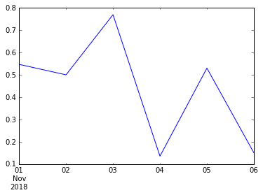

```python
# Plot prices for ADA coin
price['ADA'].plot()
```

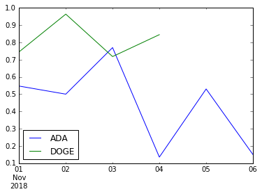

```python
# Plot several price graphs
price[['ADA', 'DOGE']].plot()
```

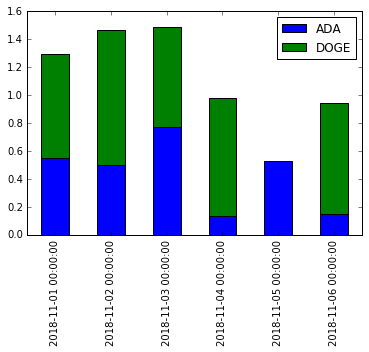

```python
# Bar chart
price.plot.bar(stacked=True)
```

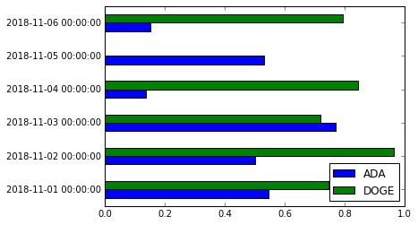

```python
# Horizontal bar chart
price.plot.barh()
```

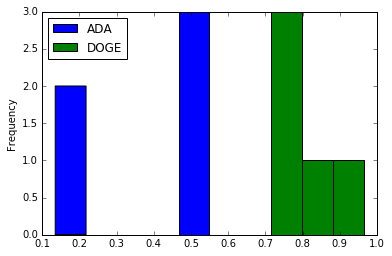

```python
# Histogram
price.plot.hist(bins=10)
```

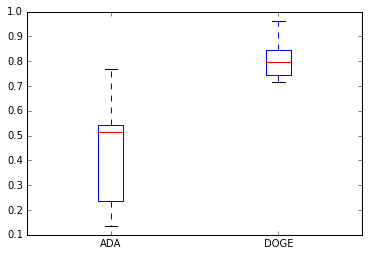

```python
# Box plot
price.plot.box()
```

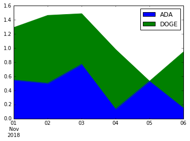

```python
# Filled plots
price.plot.area()
```

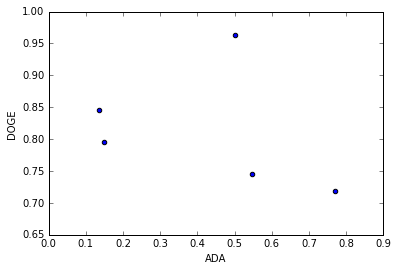

```python
# Scatter plot
price.plot.scatter(x='ADA', y='DOGE')
```

[output not shown]

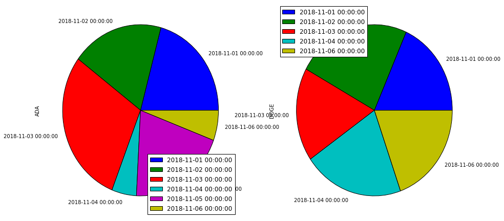

```python
# Pie chart
price.plot.pie(subplots=True, figsize=(15,7.5))
```

```python
del price
```

# NB

## Other tools to work with data

If your dataset is not too big, then pandas is de facto the best tool available. Otherwise, there are alternatives:

- [numpy](http://www.numpy.org/) - library for low-level work with multidimensional arrays of primitive data types. Suitable for "vectorized" processing. Numpy is your last chance to still write in regular python without C bindings. Suitable for tasks of fast processing of not too large data. Actually pandas uses numpy under its hood.
- [Graphlab](https://turi.com/) - Paid Python library for working with both big data and small datasets. Data is represented as SFrame objects, much like the DataFrame from pandas.
- [Hadoop](https://hadoop.apache.org/) - for working with very large data, in particular there is a classic MapReduce.

## Other visualization tools

There are many more libraries for visualization. Here are the most popular

- [Pandas](https://pandas.pydata.org/) - for quick and very easy visualization. Any customization will require knowledge of matplotlib
- [Seaborn](https://seaborn.pydata.org/) - A wide but fixed set of sophisticated visualizations with beautiful color schemes. The library is an add-on for matplotlib, and again, fine tuning will require knowledge of matplotlib.
  - [Gallery with examples](https://seaborn.pydata.org/examples/index.html)
  - [Tutorial](https://seaborn.pydata.org/tutorial.html)
- [ggplot](http://ggplot.yhathq.com/) - promising library copied from R. So far at the development stage
- [Bokeh](https://bokeh.pydata.org/en/latest/) - for visualization in web
- [Plot.ly](https://plot.ly/) - library for interactive and static visualizations. It is aimed at working in the cloud, but it can work locally.
  - [Gallery with examples](https://plot.ly/python/)
  - [Cheat sheet](https://images.plot.ly/plotly-documentation/images/python_cheat_sheet.pdf)